# R : Comparing Oversampling and Undersampling Algorithms for Class Imbalance Treatment

John Pauline Pineda

April 29, 2023

# **1. Table of Contents**

This document presents a non-exhaustive list of oversampling and undersampling algorithms applied for severe class imbalance using various helpful packages in **R**.  
Oversampling and undersampling algorithms address imbalanced classification problems by changing the data set used for model training through non-random resampling to achieve a more reasonably balanced data between the majority and minority classes. In oversampling, new instances are created from the minor class instead of merely creating copies, by selecting two or more similar instances (using a distance measure) and perturbing an instance one attribute at a time by a random amount within the difference to the neighboring instances. In undersampling, a subset of instances from the majority class is removed based on relationships between nearest neighbors by having the minimum distance in the feature space with other instances belonging to the minority classes. The algorithms applied in this study (mostly contained in the **caret**, **themis** and **ROSE** packages attempt to augment imbalanced data prior to model training by updating the original data set to minimize the effect of the disproportionate ratio of instances in each class.

## 1.1 Sample Data

The **Sonar** dataset from the **mlbench** package was used for this illustrated example. The original dataset was transformed to simulate class imbalance.  
Preliminary dataset assessment:  
**[A]** 136 rows (observations)  
**[A.1]** Train Set = 136 observations with class ratio of 80:20  
**[B]** 3 columns (variables)  
**[B.1]** 1/3 response = Class variable (factor)  
**[B.1.1]** Levels = Class=R < Class=M  
**[B.2]** 2/3 predictors = All remaining variables (2/2 numeric)

```r
##################################
# Loading R libraries
##################################
library(AppliedPredictiveModeling)
library(caret)
library(rpart)
library(lattice)
library(dplyr)
library(tidyr)
library(moments)
library(skimr)
library(RANN)
library(mlbench)
library(pls)
library(corrplot)
library(lares)
library(DMwR)
library(gridExtra)
library(rattle)
library(rpart.plot)
library(RColorBrewer)
library(stats)
library(nnet)
library(elasticnet)
library(earth)
library(party)
library(kernlab)
library(randomForest)
library(Cubist)
library(pROC)
library(ggpubr)
library(mda)
library(klaR)
library(pamr)
library(themis)
library(ROSE)

##################################
# Loading source and
# formulating the train set
##################################
data(Sonar)

Sonar.Original <- Sonar

Sonar.M <- Sonar[Sonar$Class=="M",]
Sonar.R <- Sonar[Sonar$Class=="R",]
set.seed(12345678)
Sonar.R.Reduced <- Sonar.R[sample(1:nrow(Sonar.R),25),]

Sonar <- as.data.frame(rbind(Sonar.M,Sonar.R.Reduced))
Sonar$Class <- factor(Sonar$Class,
                         levels=c("M","R"))

Sonar_Train <- Sonar[,c("Class","V1","V11")]

##################################
# Performing a general exploration of the train set
##################################
dim(Sonar_Train)
```

```
## [1] 136   3
```

```r
str(Sonar_Train)
```

```
## 'data.frame':    136 obs. of  3 variables:
##  $ Class: Factor w/ 2 levels "M","R": 1 1 1 1 1 1 1 1 1 1 ...
##  $ V1   : num  0.0491 0.1313 0.0201 0.0629 0.0335 ...
##  $ V11  : num  0.0947 0.2907 0.2251 0.5466 0.5533 ...
```

```r
summary(Sonar_Train)
```

```
##  Class         V1               V11
##  M:111   Min.   :0.00150   Min.   :0.0523
##  R: 25   1st Qu.:0.01550   1st Qu.:0.1780
##          Median :0.02365   Median :0.2503
##          Mean   :0.03188   Mean   :0.2642
##          3rd Qu.:0.03925   3rd Qu.:0.3222
##          Max.   :0.13710   Max.   :0.7342
```

```r
##################################
# Formulating a data type assessment summary
##################################
PDA <- Sonar_Train
(PDA.Summary <- data.frame(
  Column.Index=c(1:length(names(PDA))),
  Column.Name= names(PDA),
  Column.Type=sapply(PDA, function(x) class(x)),
  row.names=NULL)
)
```

```
##   Column.Index Column.Name Column.Type
## 1            1       Class      factor
## 2            2          V1     numeric
## 3            3         V11     numeric
```

## 1.2 Data Quality Assessment

Data quality assessment:  
**[A]** No missing observations noted for any variable.  
**[B]** No low variance noted with First.Second.Mode.Ratio>5.  
**[C]** No low variance noted for any variable with Unique.Count.Ratio<0.01.  
**[D]** No high skewness noted for any variable with Skewness>3 or Skewness<(-3).

```r
##################################
# Loading dataset
##################################
DQA <- Sonar_Train

##################################
# Formulating an overall data quality assessment summary
##################################
(DQA.Summary <- data.frame(
  Column.Index=c(1:length(names(DQA))),
  Column.Name= names(DQA),
  Column.Type=sapply(DQA, function(x) class(x)),
  Row.Count=sapply(DQA, function(x) nrow(DQA)),
  NA.Count=sapply(DQA,function(x)sum(is.na(x))),
  Fill.Rate=sapply(DQA,function(x)format(round((sum(!is.na(x))/nrow(DQA)),3),nsmall=3)),
  row.names=NULL)
)
```

```
##   Column.Index Column.Name Column.Type Row.Count NA.Count Fill.Rate
## 1            1       Class      factor       136        0     1.000
## 2            2          V1     numeric       136        0     1.000
## 3            3         V11     numeric       136        0     1.000
```

```r
##################################
# Listing all predictors
##################################
DQA.Predictors <- DQA[,!names(DQA) %in% c("Class")]

##################################
# Listing all numeric predictors
##################################
DQA.Predictors.Numeric <- DQA.Predictors[,sapply(DQA.Predictors, is.numeric)]

if (length(names(DQA.Predictors.Numeric))>0) {
    print(paste0("There are ",
               (length(names(DQA.Predictors.Numeric))),
               " numeric predictor variable(s)."))
} else {
  print("There are no numeric predictor variables.")
}
```

```
## [1] "There are 2 numeric predictor variable(s)."
```

```r
##################################
# Listing all factor predictors
##################################
DQA.Predictors.Factor <- DQA.Predictors[,sapply(DQA.Predictors, is.factor)]

if (length(names(DQA.Predictors.Factor))>0) {
    print(paste0("There are ",
               (length(names(DQA.Predictors.Factor))),
               " factor predictor variable(s)."))
} else {
  print("There are no factor predictor variables.")
}
```

```
## [1] "There are no factor predictor variables."
```

```r
##################################
# Formulating a data quality assessment summary for factor predictors
##################################
if (length(names(DQA.Predictors.Factor))>0) {

  ##################################
  # Formulating a function to determine the first mode
  ##################################
  FirstModes <- function(x) {
    ux <- unique(na.omit(x))
    tab <- tabulate(match(x, ux))
    ux[tab == max(tab)]
  }

  ##################################
  # Formulating a function to determine the second mode
  ##################################
  SecondModes <- function(x) {
    ux <- unique(na.omit(x))
    tab <- tabulate(match(x, ux))
    fm = ux[tab == max(tab)]
    sm = x[!(x %in% fm)]
    usm <- unique(sm)
    tabsm <- tabulate(match(sm, usm))
    ifelse(is.na(usm[tabsm == max(tabsm)])==TRUE,
           return("x"),
           return(usm[tabsm == max(tabsm)]))
  }

  (DQA.Predictors.Factor.Summary <- data.frame(
  Column.Name= names(DQA.Predictors.Factor),
  Column.Type=sapply(DQA.Predictors.Factor, function(x) class(x)),
  Unique.Count=sapply(DQA.Predictors.Factor, function(x) length(unique(x))),
  First.Mode.Value=sapply(DQA.Predictors.Factor, function(x) as.character(FirstModes(x)[1])),
  Second.Mode.Value=sapply(DQA.Predictors.Factor, function(x) as.character(SecondModes(x)[1])),
  First.Mode.Count=sapply(DQA.Predictors.Factor, function(x) sum(na.omit(x) == FirstModes(x)[1])),
  Second.Mode.Count=sapply(DQA.Predictors.Factor, function(x) sum(na.omit(x) == SecondModes(x)[1])),
  Unique.Count.Ratio=sapply(DQA.Predictors.Factor, function(x) format(round((length(unique(x))/nrow(DQA.Predictors.Factor)),3), nsmall=3)),
  First.Second.Mode.Ratio=sapply(DQA.Predictors.Factor, function(x) format(round((sum(na.omit(x) == FirstModes(x)[1])/sum(na.omit(x) == SecondModes(x)[1])),3), nsmall=3)),
  row.names=NULL)
  )

}

##################################
# Formulating a data quality assessment summary for numeric predictors
##################################
if (length(names(DQA.Predictors.Numeric))>0) {

  ##################################
  # Formulating a function to determine the first mode
  ##################################
  FirstModes <- function(x) {
    ux <- unique(na.omit(x))
    tab <- tabulate(match(x, ux))
    ux[tab == max(tab)]
  }

  ##################################
  # Formulating a function to determine the second mode
  ##################################
  SecondModes <- function(x) {
    ux <- unique(na.omit(x))
    tab <- tabulate(match(x, ux))
    fm = ux[tab == max(tab)]
    sm = na.omit(x)[!(na.omit(x) %in% fm)]
    usm <- unique(sm)
    tabsm <- tabulate(match(sm, usm))
    ifelse(is.na(usm[tabsm == max(tabsm)])==TRUE,
           return(0.00001),
           return(usm[tabsm == max(tabsm)]))
  }

  (DQA.Predictors.Numeric.Summary <- data.frame(
  Column.Name= names(DQA.Predictors.Numeric),
  Column.Type=sapply(DQA.Predictors.Numeric, function(x) class(x)),
  Unique.Count=sapply(DQA.Predictors.Numeric, function(x) length(unique(x))),
  Unique.Count.Ratio=sapply(DQA.Predictors.Numeric, function(x) format(round((length(unique(x))/nrow(DQA.Predictors.Numeric)),3), nsmall=3)),
  First.Mode.Value=sapply(DQA.Predictors.Numeric, function(x) format(round((FirstModes(x)[1]),3),nsmall=3)),
  Second.Mode.Value=sapply(DQA.Predictors.Numeric, function(x) format(round((SecondModes(x)[1]),3),nsmall=3)),
  First.Mode.Count=sapply(DQA.Predictors.Numeric, function(x) sum(na.omit(x) == FirstModes(x)[1])),
  Second.Mode.Count=sapply(DQA.Predictors.Numeric, function(x) sum(na.omit(x) == SecondModes(x)[1])),
  First.Second.Mode.Ratio=sapply(DQA.Predictors.Numeric, function(x) format(round((sum(na.omit(x) == FirstModes(x)[1])/sum(na.omit(x) == SecondModes(x)[1])),3), nsmall=3)),
  Minimum=sapply(DQA.Predictors.Numeric, function(x) format(round(min(x,na.rm = TRUE),3), nsmall=3)),
  Mean=sapply(DQA.Predictors.Numeric, function(x) format(round(mean(x,na.rm = TRUE),3), nsmall=3)),
  Median=sapply(DQA.Predictors.Numeric, function(x) format(round(median(x,na.rm = TRUE),3), nsmall=3)),
  Maximum=sapply(DQA.Predictors.Numeric, function(x) format(round(max(x,na.rm = TRUE),3), nsmall=3)),
  Skewness=sapply(DQA.Predictors.Numeric, function(x) format(round(skewness(x,na.rm = TRUE),3), nsmall=3)),
  Kurtosis=sapply(DQA.Predictors.Numeric, function(x) format(round(kurtosis(x,na.rm = TRUE),3), nsmall=3)),
  Percentile25th=sapply(DQA.Predictors.Numeric, function(x) format(round(quantile(x,probs=0.25,na.rm = TRUE),3), nsmall=3)),
  Percentile75th=sapply(DQA.Predictors.Numeric, function(x) format(round(quantile(x,probs=0.75,na.rm = TRUE),3), nsmall=3)),
  row.names=NULL)
  )

}
```

```
##   Column.Name Column.Type Unique.Count Unique.Count.Ratio First.Mode.Value
## 1          V1     numeric          122              0.897            0.020
## 2         V11     numeric          134              0.985            0.213
##   Second.Mode.Value First.Mode.Count Second.Mode.Count First.Second.Mode.Ratio
## 1             0.034                3                 2                   1.500
## 2             0.095                2                 1                   2.000
##   Minimum  Mean Median Maximum Skewness Kurtosis Percentile25th Percentile75th
## 1   0.002 0.032  0.024   0.137    1.915    6.988          0.015          0.039
## 2   0.052 0.264  0.250   0.734    0.909    4.151          0.178          0.322
```

```r
##################################
# Identifying potential data quality issues
##################################

##################################
# Checking for missing observations
##################################
if ((nrow(DQA.Summary[DQA.Summary$NA.Count>0,]))>0){
  print(paste0("Missing observations noted for ",
               (nrow(DQA.Summary[DQA.Summary$NA.Count>0,])),
               " variable(s) with NA.Count>0 and Fill.Rate<1.0."))
  DQA.Summary[DQA.Summary$NA.Count>0,]
} else {
  print("No missing observations noted.")
}
```

```
## [1] "No missing observations noted."
```

```r
##################################
# Checking for zero or near-zero variance predictors
##################################
if (length(names(DQA.Predictors.Factor))==0) {
  print("No factor predictors noted.")
} else if (nrow(DQA.Predictors.Factor.Summary[as.numeric(as.character(DQA.Predictors.Factor.Summary$First.Second.Mode.Ratio))>5,])>0){
  print(paste0("Low variance observed for ",
               (nrow(DQA.Predictors.Factor.Summary[as.numeric(as.character(DQA.Predictors.Factor.Summary$First.Second.Mode.Ratio))>5,])),
               " factor variable(s) with First.Second.Mode.Ratio>5."))
  DQA.Predictors.Factor.Summary[as.numeric(as.character(DQA.Predictors.Factor.Summary$First.Second.Mode.Ratio))>5,]
} else {
  print("No low variance factor predictors due to high first-second mode ratio noted.")
}
```

```
## [1] "No factor predictors noted."
```

```r
if (length(names(DQA.Predictors.Numeric))==0) {
  print("No numeric predictors noted.")
} else if (nrow(DQA.Predictors.Numeric.Summary[as.numeric(as.character(DQA.Predictors.Numeric.Summary$First.Second.Mode.Ratio))>5,])>0){
  print(paste0("Low variance observed for ",
               (nrow(DQA.Predictors.Numeric.Summary[as.numeric(as.character(DQA.Predictors.Numeric.Summary$First.Second.Mode.Ratio))>5,])),
               " numeric variable(s) with First.Second.Mode.Ratio>5."))
  DQA.Predictors.Numeric.Summary[as.numeric(as.character(DQA.Predictors.Numeric.Summary$First.Second.Mode.Ratio))>5,]
} else {
  print("No low variance numeric predictors due to high first-second mode ratio noted.")
}
```

```
## [1] "No low variance numeric predictors due to high first-second mode ratio noted."
```

```r
if (length(names(DQA.Predictors.Numeric))==0) {
  print("No numeric predictors noted.")
} else if (nrow(DQA.Predictors.Numeric.Summary[as.numeric(as.character(DQA.Predictors.Numeric.Summary$Unique.Count.Ratio))<0.01,])>0){
  print(paste0("Low variance observed for ",
               (nrow(DQA.Predictors.Numeric.Summary[as.numeric(as.character(DQA.Predictors.Numeric.Summary$Unique.Count.Ratio))<0.01,])),
               " numeric variable(s) with Unique.Count.Ratio<0.01."))
  DQA.Predictors.Numeric.Summary[as.numeric(as.character(DQA.Predictors.Numeric.Summary$Unique.Count.Ratio))<0.01,]
} else {
  print("No low variance numeric predictors due to low unique count ratio noted.")
}
```

```
## [1] "No low variance numeric predictors due to low unique count ratio noted."
```

```r
##################################
# Checking for skewed predictors
##################################
if (length(names(DQA.Predictors.Numeric))==0) {
  print("No numeric predictors noted.")
} else if (nrow(DQA.Predictors.Numeric.Summary[as.numeric(as.character(DQA.Predictors.Numeric.Summary$Skewness))>3 |
                                               as.numeric(as.character(DQA.Predictors.Numeric.Summary$Skewness))<(-3),])>0){
  print(paste0("High skewness observed for ",
  (nrow(DQA.Predictors.Numeric.Summary[as.numeric(as.character(DQA.Predictors.Numeric.Summary$Skewness))>3 |
                                               as.numeric(as.character(DQA.Predictors.Numeric.Summary$Skewness))<(-3),])),
  " numeric variable(s) with Skewness>3 or Skewness<(-3)."))
  DQA.Predictors.Numeric.Summary[as.numeric(as.character(DQA.Predictors.Numeric.Summary$Skewness))>3 |
                                 as.numeric(as.character(DQA.Predictors.Numeric.Summary$Skewness))<(-3),]
} else {
  print("No skewed numeric predictors noted.")
}
```

```
## [1] "No skewed numeric predictors noted."
```

## 1.3 Data Preprocessing

### 1.3.1 Outlier

Outlier data assessment:  
**[A]** Outliers noted for 2 variables with the numeric data visualized through a boxplot including observations classified as suspected outliers using the IQR criterion. The IQR criterion means that all observations above the (75th percentile + 1.5 x IQR) or below the (25th percentile - 1.5 x IQR) are suspected outliers, where IQR is the difference between the third quartile (75th percentile) and first quartile (25th percentile). Outlier treatment for numerical stability remains optional depending on potential model requirements for the subsequent steps.  
**[A.1]** V1 variable (8 outliers detected)  
**[A.2]** V11 variable (5 outliers detected)

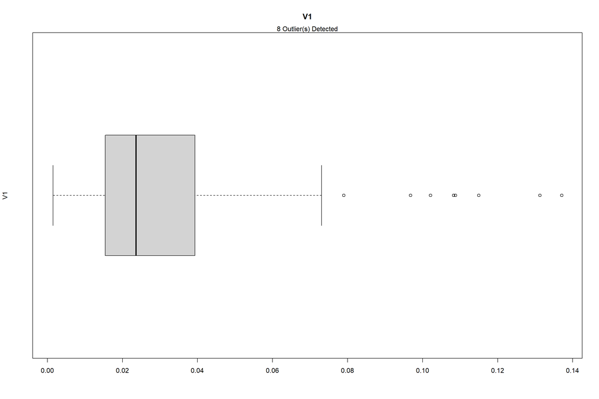

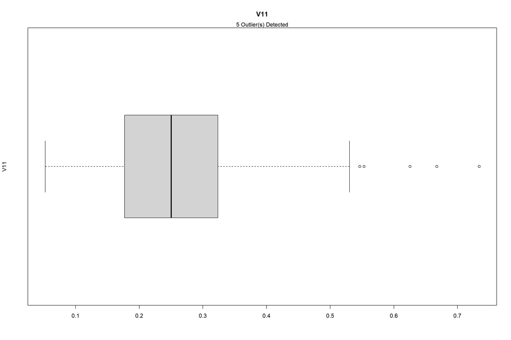

```r
##################################
# Loading dataset
##################################
DPA <- Sonar_Train

##################################
# Listing all predictors
##################################
DPA.Predictors <- DPA[,!names(DPA) %in% c("Class")]

##################################
# Listing all numeric predictors
##################################
DPA.Predictors.Numeric <- DPA.Predictors[,sapply(DPA.Predictors, is.numeric)]

##################################
# Identifying outliers for the numeric predictors
##################################
OutlierCountList <- c()

for (i in 1:ncol(DPA.Predictors.Numeric)) {
  Outliers <- boxplot.stats(DPA.Predictors.Numeric[,i])$out
  OutlierCount <- length(Outliers)
  OutlierCountList <- append(OutlierCountList,OutlierCount)
  OutlierIndices <- which(DPA.Predictors.Numeric[,i] %in% c(Outliers))
  boxplot(DPA.Predictors.Numeric[,i],
          ylab = names(DPA.Predictors.Numeric)[i],
          main = names(DPA.Predictors.Numeric)[i],
          horizontal=TRUE)
  mtext(paste0(OutlierCount, " Outlier(s) Detected"))
}
```

```r
OutlierCountSummary <- as.data.frame(cbind(names(DPA.Predictors.Numeric),(OutlierCountList)))
names(OutlierCountSummary) <- c("NumericPredictors","OutlierCount")
OutlierCountSummary$OutlierCount <- as.numeric(as.character(OutlierCountSummary$OutlierCount))
NumericPredictorWithOutlierCount <- nrow(OutlierCountSummary[OutlierCountSummary$OutlierCount>0,])
print(paste0(NumericPredictorWithOutlierCount, " numeric variable(s) were noted with outlier(s)." ))
```

```
## [1] "2 numeric variable(s) were noted with outlier(s)."
```

```r
##################################
# Gathering descriptive statistics
##################################
(DPA_Skimmed <- skim(DPA.Predictors.Numeric))
```

Data summary

| Name | DPA.Predictors.Numeric |
| --- | --- |
| Number of rows | 136 |
| Number of columns | 2 |
| _______________________ |  |
| Column type frequency: |  |
| numeric | 2 |
| ________________________ |  |
| Group variables | None |

**Variable type: numeric**

| skim_variable | n_missing | complete_rate | mean | sd | p0 | p25 | p50 | p75 | p100 | hist |
| --- | --- | --- | --- | --- | --- | --- | --- | --- | --- | --- |
| V1 | 0 | 1 | 0.03 | 0.03 | 0.00 | 0.02 | 0.02 | 0.04 | 0.14 | ▇▃▁▁▁ |
| V11 | 0 | 1 | 0.26 | 0.13 | 0.05 | 0.18 | 0.25 | 0.32 | 0.73 | ▅▇▂▁▁ |

```r
###################################
# Verifying the data dimensions
###################################
dim(DPA.Predictors.Numeric)
```

```
## [1] 136   2
```

### 1.3.2 Zero and Near-Zero Variance

Zero and near-zero variance data assessment:  
**[A]** No low variance noted for any variable from the previous data quality assessment using a lower threshold.  
**[B]** No low variance noted for any variables using a preprocessing summary from the **caret** package. The nearZeroVar method using both the freqCut and uniqueCut criteria set at 95/5 and 10, respectively, were applied on the dataset.

```r
##################################
# Loading dataset
##################################
DPA <- Sonar_Train

##################################
# Gathering descriptive statistics
##################################
(DPA_Skimmed <- skim(DPA))
```

Data summary

| Name | DPA |
| --- | --- |
| Number of rows | 136 |
| Number of columns | 3 |
| _______________________ |  |
| Column type frequency: |  |
| factor | 1 |
| numeric | 2 |
| ________________________ |  |
| Group variables | None |

**Variable type: factor**

| skim_variable | n_missing | complete_rate | ordered | n_unique | top_counts |
| --- | --- | --- | --- | --- | --- |
| Class | 0 | 1 | FALSE | 2 | M: 111, R: 25 |

**Variable type: numeric**

| skim_variable | n_missing | complete_rate | mean | sd | p0 | p25 | p50 | p75 | p100 | hist |
| --- | --- | --- | --- | --- | --- | --- | --- | --- | --- | --- |
| V1 | 0 | 1 | 0.03 | 0.03 | 0.00 | 0.02 | 0.02 | 0.04 | 0.14 | ▇▃▁▁▁ |
| V11 | 0 | 1 | 0.26 | 0.13 | 0.05 | 0.18 | 0.25 | 0.32 | 0.73 | ▅▇▂▁▁ |

```r
##################################
# Identifying columns with low variance
###################################
DPA_LowVariance <- nearZeroVar(DPA,
                               freqCut = 95/5,
                               uniqueCut = 10,
                               saveMetrics= TRUE)
(DPA_LowVariance[DPA_LowVariance$nzv,])
```

```
## [1] freqRatio     percentUnique zeroVar       nzv
## <0 rows> (or 0-length row.names)
```

```r
if ((nrow(DPA_LowVariance[DPA_LowVariance$nzv,]))==0){

  print("No low variance predictors noted.")

} else {

  print(paste0("Low variance observed for ",
               (nrow(DPA_LowVariance[DPA_LowVariance$nzv,])),
               " numeric variable(s) with First.Second.Mode.Ratio>4 and Unique.Count.Ratio<0.10."))

  DPA_LowVarianceForRemoval <- (nrow(DPA_LowVariance[DPA_LowVariance$nzv,]))

  print(paste0("Low variance can be resolved by removing ",
               (nrow(DPA_LowVariance[DPA_LowVariance$nzv,])),
               " numeric variable(s)."))

  for (j in 1:DPA_LowVarianceForRemoval) {
  DPA_LowVarianceRemovedVariable <- rownames(DPA_LowVariance[DPA_LowVariance$nzv,])[j]
  print(paste0("Variable ",
               j,
               " for removal: ",
               DPA_LowVarianceRemovedVariable))
  }

  DPA %>%
  skim() %>%
  dplyr::filter(skim_variable %in% rownames(DPA_LowVariance[DPA_LowVariance$nzv,]))

  ##################################
  # Filtering out columns with low variance
  #################################
  DPA_ExcludedLowVariance <- DPA[,!names(DPA) %in% rownames(DPA_LowVariance[DPA_LowVariance$nzv,])]

  ##################################
  # Gathering descriptive statistics
  ##################################
  (DPA_ExcludedLowVariance_Skimmed <- skim(DPA_ExcludedLowVariance))

  ###################################
  # Verifying the data dimensions
  ###################################
  dim(DPA_ExcludedLowVariance)

}
```

```
## [1] "No low variance predictors noted."
```

### 1.3.3 Collinearity

High collinearity data assessment:  
**[A]** No high correlation > 95% were noted for any variable as confirmed using the preprocessing summaries from the **caret** and **lares** packages.

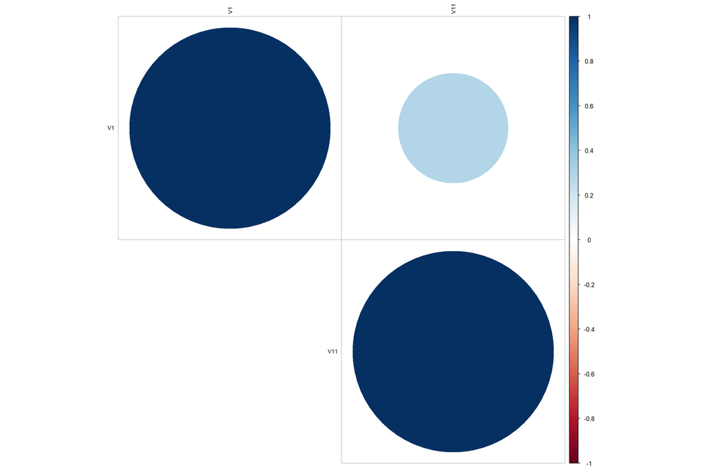

```r
##################################
# Loading dataset
##################################
DPA <- Sonar_Train

##################################
# Listing all predictors
##################################
DPA.Predictors <- DPA[,!names(DPA) %in% c("Class")]

##################################
# Listing all numeric predictors
##################################
DPA.Predictors.Numeric <- DPA.Predictors[,sapply(DPA.Predictors, is.numeric)]

##################################
# Visualizing pairwise correlation between predictors
##################################
DPA_CorrelationTest <- cor.mtest(DPA.Predictors.Numeric,
                       method = "pearson",
                       conf.level = .95)

corrplot(cor(DPA.Predictors.Numeric,
             method = "pearson",
             use="pairwise.complete.obs"),
         method = "circle",
         type = "upper",
         order = "original",
         tl.col = "black",
         tl.cex = 0.75,
         tl.srt = 90,
         sig.level = 0.05,
         p.mat = DPA_CorrelationTest$p,
         insig = "blank")
```

```r
##################################
# Identifying the highly correlated variables
##################################
DPA_Correlation <-  cor(DPA.Predictors.Numeric,
                        method = "pearson",
                        use="pairwise.complete.obs")
(DPA_HighlyCorrelatedCount <- sum(abs(DPA_Correlation[upper.tri(DPA_Correlation)]) > 0.95))
```

```
## [1] 0
```

```r
if (DPA_HighlyCorrelatedCount == 0) {

  print("No highly correlated predictors noted.")

} else {
  print(paste0("High correlation observed for ",
               (DPA_HighlyCorrelatedCount),
               " pairs of numeric variable(s) with Correlation.Coefficient>0.95."))

  (DPA_HighlyCorrelatedPairs <- corr_cross(DPA.Predictors.Numeric,
  max_pvalue = 0.05,
  top = DPA_HighlyCorrelatedCount,
  rm.na = TRUE,
  grid = FALSE
))

}
```

```
## [1] "No highly correlated predictors noted."
```

```r
if (DPA_HighlyCorrelatedCount > 0) {
  DPA_HighlyCorrelated <- findCorrelation(DPA_Correlation, cutoff = 0.95)

  (DPA_HighlyCorrelatedForRemoval <- length(DPA_HighlyCorrelated))

  print(paste0("High correlation can be resolved by removing ",
               (DPA_HighlyCorrelatedForRemoval),
               " numeric variable(s)."))

  for (j in 1:DPA_HighlyCorrelatedForRemoval) {
  DPA_HighlyCorrelatedRemovedVariable <- colnames(DPA.Predictors.Numeric)[DPA_HighlyCorrelated[j]]
  print(paste0("Variable ",
               j,
               " for removal: ",
               DPA_HighlyCorrelatedRemovedVariable))
  }

  ##################################
  # Filtering out columns with high correlation
  #################################
  DPA_ExcludedHighCorrelation <- DPA[,-DPA_HighlyCorrelated]

  ##################################
  # Gathering descriptive statistics
  ##################################
  (DPA_ExcludedHighCorrelation_Skimmed <- skim(DPA_ExcludedHighCorrelation))

  ###################################
  # Verifying the data dimensions
  ###################################
  dim(DPA_ExcludedHighCorrelation)

}
```

### 1.3.4 Linear Dependencies

Linear dependency data assessment:  
**[A]** No linear dependencies noted for any subset of variables using the preprocessing summary from the **caret** package applying the findLinearCombos method which utilizes the QR decomposition of a matrix to enumerate sets of linear combinations (if they exist).

```r
##################################
# Loading dataset
##################################
DPA <- Sonar_Train

##################################
# Listing all predictors
##################################
DPA.Predictors <- DPA[,!names(DPA) %in% c("Class")]

##################################
# Listing all numeric predictors
##################################
DPA.Predictors.Numeric <- DPA.Predictors[,sapply(DPA.Predictors, is.numeric)]

##################################
# Identifying the linearly dependent variables
##################################
DPA_LinearlyDependent <- findLinearCombos(DPA.Predictors.Numeric)

(DPA_LinearlyDependentCount <- length(DPA_LinearlyDependent$linearCombos))
```

```
## [1] 0
```

```r
if (DPA_LinearlyDependentCount == 0) {
  print("No linearly dependent predictors noted.")
} else {
  print(paste0("Linear dependency observed for ",
               (DPA_LinearlyDependentCount),
               " subset(s) of numeric variable(s)."))

  for (i in 1:DPA_LinearlyDependentCount) {
    DPA_LinearlyDependentSubset <- colnames(DPA.Predictors.Numeric)[DPA_LinearlyDependent$linearCombos[[i]]]
    print(paste0("Linear dependent variable(s) for subset ",
                 i,
                 " include: ",
                 DPA_LinearlyDependentSubset))
  }

}
```

```
## [1] "No linearly dependent predictors noted."
```

```r
##################################
# Identifying the linearly dependent variables for removal
##################################

if (DPA_LinearlyDependentCount > 0) {
  DPA_LinearlyDependent <- findLinearCombos(DPA.Predictors.Numeric)

  DPA_LinearlyDependentForRemoval <- length(DPA_LinearlyDependent$remove)

  print(paste0("Linear dependency can be resolved by removing ",
               (DPA_LinearlyDependentForRemoval),
               " numeric variable(s)."))

  for (j in 1:DPA_LinearlyDependentForRemoval) {
  DPA_LinearlyDependentRemovedVariable <- colnames(DPA.Predictors.Numeric)[DPA_LinearlyDependent$remove[j]]
  print(paste0("Variable ",
               j,
               " for removal: ",
               DPA_LinearlyDependentRemovedVariable))
  }

  ##################################
  # Filtering out columns with linear dependency
  #################################
  DPA_ExcludedLinearlyDependent <- DPA[,-DPA_LinearlyDependent$remove]

  ##################################
  # Gathering descriptive statistics
  ##################################
  (DPA_ExcludedLinearlyDependent_Skimmed <- skim(DPA_ExcludedLinearlyDependent))

  ###################################
  # Verifying the data dimensions
  ###################################
  dim(DPA_ExcludedLinearlyDependent)

} else {

  ###################################
  # Verifying the data dimensions
  ###################################
  dim(DPA)

}
```

```
## [1] 136   3
```

### 1.3.5 Shape Transformation

Data transformation assessment:  
**[A]** A number of numeric variables in the dataset were observed to be right-skewed which required shape transformation for data distribution stability. Considering that all numeric variables were strictly positive values, the BoxCox method from the **caret** package was used to transform their distributional shapes.

```r
##################################
# Loading dataset
##################################
DPA <- Sonar_Train

##################################
# Listing all predictors
##################################
DPA.Predictors <- DPA[,!names(DPA) %in% c("Class")]

##################################
# Listing all numeric predictors
##################################
DPA.Predictors.Numeric <- DPA.Predictors[,sapply(DPA.Predictors, is.numeric)]

##################################
# Applying a Box-Cox transformation
##################################
DPA_BoxCox <- preProcess(DPA.Predictors.Numeric, method = c("BoxCox"))
DPA_BoxCoxTransformed <- predict(DPA_BoxCox, DPA.Predictors.Numeric)

##################################
# Gathering descriptive statistics
##################################
(DPA_BoxCoxTransformedSkimmed <- skim(DPA_BoxCoxTransformed))
```

Data summary

| Name | DPA_BoxCoxTransformed |
| --- | --- |
| Number of rows | 136 |
| Number of columns | 2 |
| _______________________ |  |
| Column type frequency: |  |
| numeric | 2 |
| ________________________ |  |
| Group variables | None |

**Variable type: numeric**

| skim_variable | n_missing | complete_rate | mean | sd | p0 | p25 | p50 | p75 | p100 | hist |
| --- | --- | --- | --- | --- | --- | --- | --- | --- | --- | --- |
| V1 | 0 | 1 | -3.73 | 0.78 | -6.50 | -4.17 | -3.74 | -3.24 | -1.99 | ▁▁▇▇▂ |
| V11 | 0 | 1 | -1.07 | 0.29 | -1.73 | -1.25 | -1.06 | -0.91 | -0.29 | ▂▃▇▂▁ |

```r
###################################
# Verifying the data dimensions
###################################
dim(DPA_BoxCoxTransformed)
```

```
## [1] 136   2
```

### 1.3.6 Centering and Scaling

Centering and scaling data assessment:  
**[A]** To maintain numerical stability during modelling, centering and scaling transformations were applied on the transformed numeric variables. The center method from the **caret** package was implemented which subtracts the average value of a numeric variable to all the values. As a result of centering, the variables had zero mean values. In addition, the scale method, also from the **caret** package, was applied which performs a center transformation with each value of the variable divided by its standard deviation. Scaling the data coerced the values to have a common standard deviation of one.

```r
##################################
# Loading dataset
##################################
DPA <- Sonar_Train

##################################
# Listing all predictors
##################################
DPA.Predictors <- DPA[,!names(DPA) %in% c("Class")]

##################################
# Listing all numeric predictors
##################################
DPA.Predictors.Numeric <- DPA.Predictors[,sapply(DPA.Predictors, is.numeric)]

##################################
# Applying a Box-Cox transformation
##################################
DPA_BoxCox <- preProcess(DPA.Predictors.Numeric, method = c("BoxCox"))
DPA_BoxCoxTransformed <- predict(DPA_BoxCox, DPA.Predictors.Numeric)

##################################
# Applying a center and scale data transformation
##################################
DPA.Predictors.Numeric_BoxCoxTransformed_CenteredScaled <- preProcess(DPA_BoxCoxTransformed, method = c("center","scale"))
DPA.Predictors.Numeric_BoxCoxTransformed_CenteredScaledTransformed <- predict(DPA.Predictors.Numeric_BoxCoxTransformed_CenteredScaled, DPA_BoxCoxTransformed)

##################################
# Gathering descriptive statistics
##################################
(DPA.Predictors.Numeric_BoxCoxTransformed_CenteredScaledTransformedSkimmed <- skim(DPA.Predictors.Numeric_BoxCoxTransformed_CenteredScaledTransformed))
```

Data summary

| Name | DPA.Predictors.Numeric_Bo… |
| --- | --- |
| Number of rows | 136 |
| Number of columns | 2 |
| _______________________ |  |
| Column type frequency: |  |
| numeric | 2 |
| ________________________ |  |
| Group variables | None |

**Variable type: numeric**

| skim_variable | n_missing | complete_rate | mean | sd | p0 | p25 | p50 | p75 | p100 | hist |
| --- | --- | --- | --- | --- | --- | --- | --- | --- | --- | --- |
| V1 | 0 | 1 | 0 | 1 | -3.56 | -0.56 | -0.02 | 0.63 | 2.23 | ▁▁▇▇▂ |
| V11 | 0 | 1 | 0 | 1 | -2.27 | -0.59 | 0.04 | 0.57 | 2.71 | ▂▃▇▂▁ |

```r
###################################
# Verifying the data dimensions
###################################
dim(DPA.Predictors.Numeric_BoxCoxTransformed_CenteredScaledTransformed)
```

```
## [1] 136   2
```

### 1.3.7 Pre-Processed Dataset

Preliminary dataset assessment:  
**[A]** 136 rows (observations)  
**[A.1]** Train Set = 136 observations with class ratio of 80:20  
**[B]** 3 columns (variables)  
**[B.1]** 1/3 response = Class variable (factor)  
**[B.1.1]** Levels = Class=R < Class=M  
**[B.2]** 2/3 predictors = All remaining variables (2/2 numeric)  
**[C]** Pre-processing actions applied:  
**[C.1]** Centering, scaling and shape transformation applied to improve data quality  
**[C.2]** No outlier treatment applied since the high values noted were contextually valid and sensible  
**[C.3]** No predictors removed due to zero or near-zero variance  
**[C.4]** No predictors removed due to high correlation  
**[C.5]** No predictors removed due to linear dependencies

```r
##################################
# Creating the pre-modelling
# train set
##################################
Class <- DPA$Class
PMA.Predictors.Numeric  <- DPA.Predictors.Numeric_BoxCoxTransformed_CenteredScaledTransformed
PMA_BoxCoxTransformed_CenteredScaledTransformed <- cbind(Class,PMA.Predictors.Numeric)
PMA_PreModelling_Train <- PMA_BoxCoxTransformed_CenteredScaledTransformed

##################################
# Gathering descriptive statistics
##################################
(PMA_PreModelling_Train_Skimmed <- skim(PMA_PreModelling_Train))
```

Data summary

| Name | PMA_PreModelling_Train |
| --- | --- |
| Number of rows | 136 |
| Number of columns | 3 |
| _______________________ |  |
| Column type frequency: |  |
| factor | 1 |
| numeric | 2 |
| ________________________ |  |
| Group variables | None |

**Variable type: factor**

| skim_variable | n_missing | complete_rate | ordered | n_unique | top_counts |
| --- | --- | --- | --- | --- | --- |
| Class | 0 | 1 | FALSE | 2 | M: 111, R: 25 |

**Variable type: numeric**

| skim_variable | n_missing | complete_rate | mean | sd | p0 | p25 | p50 | p75 | p100 | hist |
| --- | --- | --- | --- | --- | --- | --- | --- | --- | --- | --- |
| V1 | 0 | 1 | 0 | 1 | -3.56 | -0.56 | -0.02 | 0.63 | 2.23 | ▁▁▇▇▂ |
| V11 | 0 | 1 | 0 | 1 | -2.27 | -0.59 | 0.04 | 0.57 | 2.71 | ▂▃▇▂▁ |

```r
###################################
# Verifying the data dimensions
# for the train set
###################################
dim(PMA_PreModelling_Train)
```

```
## [1] 136   3
```

## 1.4 Data Exploration

Exploratory data analysis:  
**[A]** Numeric variables which demonstrated a differential relationships with the Class response variable include:  
**[A.1]** V1 variable (numeric)  
**[A.2]** V11 variable (numeric)

```r
##################################
# Loading dataset
##################################
EDA <- PMA_PreModelling_Train

##################################
# Listing all predictors
##################################
EDA.Predictors <- EDA[,!names(EDA) %in% c("Class")]

##################################
# Listing all numeric predictors
##################################
EDA.Predictors.Numeric <- EDA.Predictors[,sapply(EDA.Predictors, is.numeric)]
ncol(EDA.Predictors.Numeric)
```

```
## [1] 2
```

```r
names(EDA.Predictors.Numeric)
```

```
## [1] "V1"  "V11"
```

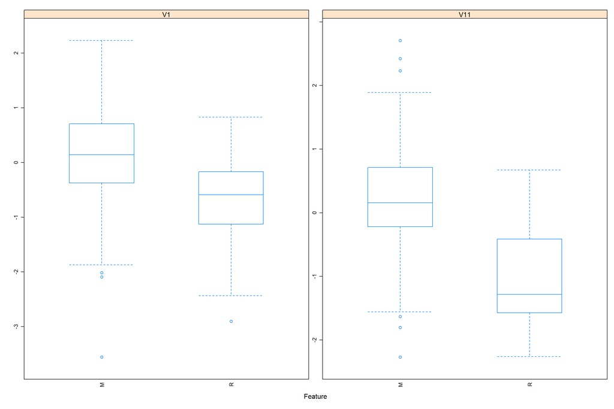

```r
##################################
# Formulating the box plots
##################################
featurePlot(x = EDA.Predictors.Numeric,
            y = EDA$Class,
            plot = "box",
            scales = list(x = list(relation="free", rot = 90),
                          y = list(relation="free")),
            adjust = 1.5,
            pch = "|")
```

## 1.5 Oversampling and Undersampling Algorithms Applied for Class Imbalance using Logistic Regression

### 1.5.1 Original Data (REF)

```r
##################################
# Creating a local object
# for the train set
##################################
PMA_PreModelling_Train_LR <- PMA_PreModelling_Train
PMA_PreModelling_Train_LR$Label <- rep("LR",nrow(PMA_PreModelling_Train_LR))

##################################
# Verifying the class distribution
# for the original data
##################################
table(PMA_PreModelling_Train_LR$Class)
```

```
##
##   M   R
## 111  25
```

```r
##################################
# Formulating the structure of the
# Logistic Regression model
##################################
LR_Model <- glm(Class ~ V1 + V11,
                data = PMA_PreModelling_Train_LR,
                family = binomial)

##################################
# Consolidating the model results
##################################
summary(LR_Model)
```

```
##
## Call:
## glm(formula = Class ~ V1 + V11, family = binomial, data = PMA_PreModelling_Train_LR)
##
## Deviance Residuals:
##      Min        1Q    Median        3Q       Max
## -1.62998  -0.53562  -0.29014  -0.08872   2.55270
##
## Coefficients:
##             Estimate Std. Error z value Pr(>|z|)
## (Intercept)  -2.3152     0.3771  -6.139 8.28e-10 ***
## V1           -0.7399     0.3005  -2.462   0.0138 *
## V11          -1.5607     0.3450  -4.524 6.07e-06 ***
## ---
## Signif. codes:  0 '***' 0.001 '**' 0.01 '*' 0.05 '.' 0.1 ' ' 1
##
## (Dispersion parameter for binomial family taken to be 1)
##
##     Null deviance: 129.783  on 135  degrees of freedom
## Residual deviance:  88.923  on 133  degrees of freedom
## AIC: 94.923
##
## Number of Fisher Scoring iterations: 6
```

```r
LR_Model_Coef <- (as.data.frame(LR_Model$coefficients))
LR_Model_Coef$Coef <- rownames(LR_Model_Coef)
LR_Model_Coef$Model <- rep("LR",nrow(LR_Model_Coef))
colnames(LR_Model_Coef) <- c("Estimates","Coefficients","Model")
print(LR_Model_Coef, rownames=FALSE)
```

```
##              Estimates Coefficients Model
## (Intercept) -2.3152181  (Intercept)    LR
## V1          -0.7399005           V1    LR
## V11         -1.5607048          V11    LR
```

```r
##################################
# Computing the model predictions
##################################
(LR_Model_Probabilities <- predict(LR_Model,
                              type = c("response")))
```

```
##           98           99          100          101          102          103
## 0.3637496537 0.0113931997 0.1319142547 0.0021783355 0.0037538060 0.0174606489
##          104          105          106          107          108          109
## 0.0725273351 0.0164891503 0.1569862922 0.4818797362 0.2583425943 0.1252724633
##          110          111          112          113          114          115
## 0.4112142881 0.4680556213 0.1332256210 0.0344698396 0.1348432397 0.1615191484
##          116          117          118          119          120          121
## 0.0662797277 0.2436188082 0.0780323151 0.1104267965 0.0515700587 0.1445535907
##          122          123          124          125          126          127
## 0.1731460430 0.0558634929 0.1081612509 0.0165343094 0.0369004305 0.0031146384
##          128          129          130          131          132          133
## 0.0221776030 0.0200623323 0.0028456905 0.0126580025 0.0050535349 0.0081982533
##          134          135          136          137          138          139
## 0.0025368869 0.0014777580 0.0799936459 0.0023418015 0.0008311849 0.0846443282
##          140          141          142          143          144          145
## 0.2606104200 0.1780753538 0.0394327767 0.0403610789 0.0364744270 0.7351055523
##          146          147          148          149          150          151
## 0.0306057253 0.0228736619 0.0552988212 0.0205374459 0.2190542623 0.2301893864
##          152          153          154          155          156          157
## 0.1183496315 0.1771452296 0.3898752302 0.5789364640 0.6505131954 0.1549759240
##          158          159          160          161          162          163
## 0.1418070654 0.0908007706 0.0533759775 0.0797056569 0.0996424369 0.1113892912
##          164          165          166          167          168          169
## 0.2325914484 0.0352838163 0.0868721918 0.2269151196 0.5811364344 0.6804246275
##          170          171          172          173          174          175
## 0.2377989316 0.1546431081 0.0039867863 0.0484288031 0.0350025026 0.0115543490
##          176          177          178          179          180          181
## 0.0124263395 0.0040952633 0.0623582127 0.2442298264 0.0289787190 0.0051456066
##          182          183          184          185          186          187
## 0.0192102410 0.0354944115 0.0420803608 0.0020214950 0.0046310125 0.0336330699
##          188          189          190          191          192          193
## 0.0359277781 0.1172950153 0.1419944753 0.1265297826 0.1047718509 0.2755585363
##          194          195          196          197          198          199
## 0.1390569085 0.0450510742 0.1550648867 0.2872791732 0.0821006438 0.0726099031
##          200          201          202          203          204          205
## 0.0792285656 0.0532267024 0.0299770042 0.0173915161 0.0553203581 0.0345232209
##          206          207          208           95           57           27
## 0.0333086574 0.0446830571 0.0622826685 0.8967905106 0.2407267465 0.6874636823
##           18           68           92           43           87           64
## 0.4352384578 0.4517614566 0.0687256353 0.6033006196 0.1583196380 0.7793277803
##           16           12           61           13           34           66
## 0.0727076286 0.8563207774 0.3983590501 0.7017484676 0.3096802387 0.8196244700
##           49           94           91           72           23           39
## 0.3431752805 0.0384599213 0.0861723774 0.8744789160 0.4935529921 0.5807289286
##           29           73           77           32
## 0.0739144263 0.5017946378 0.5358622581 0.3382071510
```

```r
##################################
# Creating a classification index
# based from the model predictions
##################################
(LR_Model_Indices <- predict(LR_Model,
                           type = c("link")))
```

```
##           98           99          100          101          102          103
## -0.559126246 -4.463280018 -1.884138369 -6.127013509 -5.581224150 -4.030190682
##          104          105          106          107          108          109
## -2.548499795 -4.088426063 -1.680824728 -0.072512812 -1.054600830 -1.943421380
##          110          111          112          113          114          115
## -0.358947840 -0.127951795 -1.872734622 -3.332592613 -1.858797800 -1.646968043
##          116          117          118          119          120          121
## -2.645292815 -1.132940729 -2.469387136 -2.086388975 -2.911866678 -1.777973140
##          122          123          124          125          126          127
## -1.563492668 -2.827359673 -2.109662164 -4.085645174 -3.261933584 -5.768522713
##          128          129          130          131          132          133
## -3.786245149 -3.888644925 -5.859099785 -4.356726856 -5.282600962 -4.795602114
##          134          135          136          137          138          139
## -5.974277480 -6.515750374 -2.442433371 -6.054490239 -7.091826715 -2.380854599
##          140          141          142          143          144          145
## -1.042798305 -1.529441923 -3.192926600 -3.168691163 -3.273987644  1.020682662
##          146          147          148          149          150          151
## -3.455484324 -3.754629841 -2.838117074 -3.864754157 -1.271186197 -1.207242139
##          152          153          154          155          156          157
## -2.008152348 -1.535809819 -0.447836712  0.318408998  0.621295777 -1.696095344
##          158          159          160          161          162          163
## -1.800361500 -2.303896473 -2.875541209 -2.446352996 -2.201203830 -2.076628048
##          164          165          166          167          168          169
## -1.193735847 -3.308409550 -2.352437879 -1.225812824  0.327440308  0.755723902
##          170          171          172          173          174          175
## -1.164784899 -1.698638961 -5.520775067 -2.978019769 -3.316705945 -4.449071761
##          176          177          178          179          180          181
## -4.375432715 -5.493820583 -2.710472604 -1.129627633 -3.511786651 -5.264453127
##          182          183          184          185          186          187
## -3.932914599 -3.302240366 -3.125182749 -6.201894377 -5.370337994 -3.358033801
##          188          189          190          191          192          193
## -3.289655451 -2.018298780 -1.798822388 -1.931996317 -2.145293464 -0.966600884
##          194          195          196          197          198          199
## -1.823145144 -3.053861030 -1.695416182 -0.908635325 -2.414141893 -2.547272974
##          200          201          202          203          204          205
## -2.452874924 -2.878499479 -3.476889218 -4.034228249 -2.837704887 -3.330989885
##          206          207          208           95           57           27
## -3.368061909 -3.062448770 -2.711765358  2.162061490 -1.148699272  0.788288323
##           18           68           92           43           87           64
## -0.260509533 -0.193556201 -2.606431655  0.419236847 -1.670784310  1.261753296
##           16           12           61           13           34           66
## -2.545822600  1.785061852 -0.412307104  0.855637833 -0.801614636  1.513805316
##           49           94           91           72           23           39
## -0.649175855 -3.218919553 -2.361292279  1.941154440 -0.025789461  0.325766429
##           29           73           77           32
## -2.528058620  0.007178582  0.143695781 -0.671294010
```

```r
max(LR_Model_Indices)
```

```
## [1] 2.162061
```

```r
min(LR_Model_Indices)
```

```
## [1] -7.091827
```

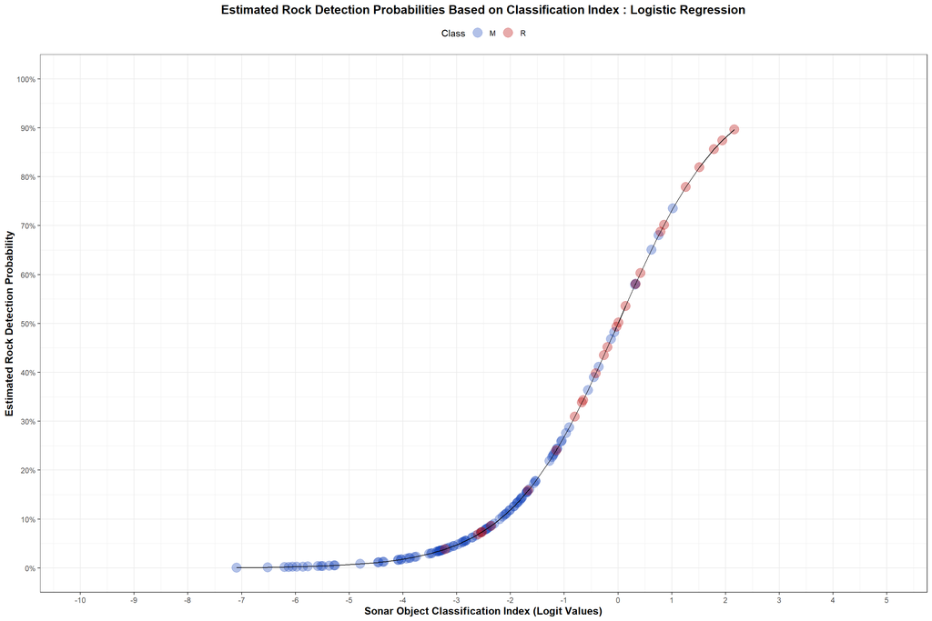

```r
##################################
# Consolidating the model probabilities
# and classification index
# based from the model predictions
##################################
LR_Model_Predictions <- as.data.frame(PMA_PreModelling_Train_LR)
LR_Model_Predictions$LR_Prob <- LR_Model_Probabilities
LR_Model_Predictions$LR_LP <- LR_Model_Indices
LR_Model_Predictions$Class <- as.factor(LR_Model_Predictions$Class)
LR_Model_Predictions$Label <- rep("LR",nrow(LR_Model_Predictions))

##################################
# Formulating the probability curve
# using the consolidated model predictions
##################################
LR_Model_Predictions %>%
  ggplot(aes(x = LR_LP ,
             y = LR_Prob,
             color = Class)) +
  scale_colour_manual(values=c("#1846BA55","#B8000055")) +
  geom_point(size=5) +
  geom_line(color="black") +
  xlab("Sonar Object Classification Index (Logit Values)") +
  ylab("Estimated Rock Detection Probability") +
  labs(color = "Class") +
  scale_x_continuous( limits=c(-10,5), breaks=seq(-10,5,by=1)) +
  scale_y_continuous( limits=c(0,1), breaks=seq(0,1,by=0.1),labels = scales::percent) +
  ggtitle("Estimated Rock Detection Probabilities Based on Classification Index : Logistic Regression") +
  theme_bw() +
  theme(plot.title = element_text(color="black", size=14, face="bold", hjust=0.50),
        axis.title.x = element_text(color="black", size=12, face="bold"),
        axis.title.y = element_text(color="black", size=12, face="bold"),
        legend.position="top")
```

### 1.5.2 Undersampling - Near Miss Algorithm (US_NEARMISS)

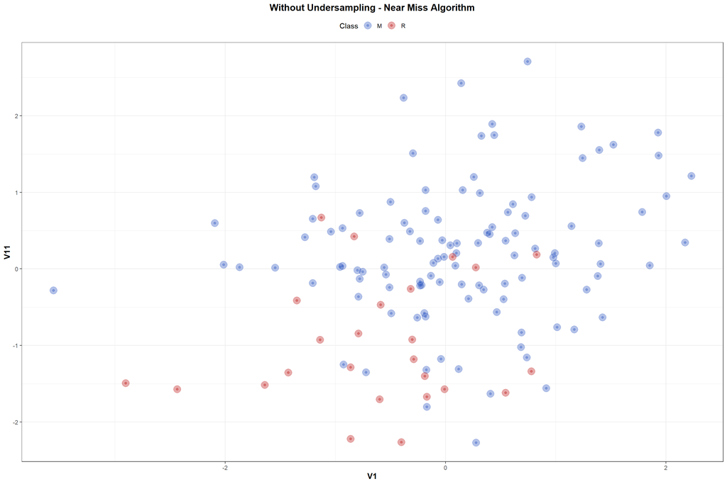

```r
##################################
# Visualizing the imbalanced data set
##################################
ggplot(PMA_PreModelling_Train, aes(V1, V11, color = Class)) +
  geom_point() +
  scale_colour_manual(values=c("#1846BA55","#B8000055")) +
  geom_point(size=5) +
  labs(title = "Without Undersampling - Near Miss Algorithm") +
  theme_bw() +
  theme(plot.title = element_text(color="black", size=14, face="bold", hjust=0.50),
        axis.title.x = element_text(color="black", size=12, face="bold"),
        axis.title.y = element_text(color="black", size=12, face="bold"),
        legend.position="top")
```

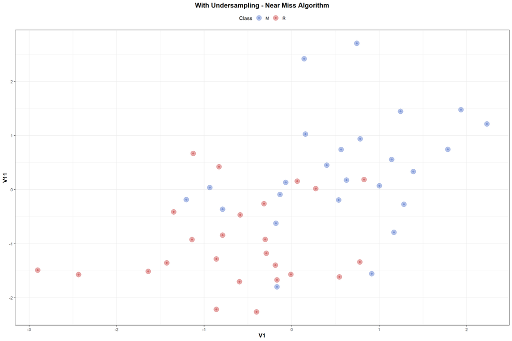

```r
##################################
# Implementing US_NEARMISS
# Visualizing the undersampled data using US_NEARMISS
##################################
recipe(Class ~ V1 + V11, data = PMA_PreModelling_Train) %>%
  step_nearmiss(Class, seed=123456789) %>%
  prep() %>%
  bake(new_data = NULL) %>%
  ggplot(aes(V1, V11, color = Class)) +
  geom_point() +
  scale_colour_manual(values=c("#1846BA55","#B8000055")) +
  geom_point(size=5) +
  labs(title = "With Undersampling - Near Miss Algorithm") +
  theme_bw() +
  theme(plot.title = element_text(color="black", size=14, face="bold", hjust=0.50),
        axis.title.x = element_text(color="black", size=12, face="bold"),
        axis.title.y = element_text(color="black", size=12, face="bold"),
        legend.position="top")
```

```r
US_NEARMISS <- recipe(Class ~ V1 + V11, data = PMA_PreModelling_Train) %>%
  step_nearmiss(Class, seed=123456789) %>%
  prep()

PMA_PreModelling_Train_LR_US_NEARMISS <- US_NEARMISS %>%
bake(new_data = NULL)

(PMA_PreModelling_Train_LR_US_NEARMISS <- as.data.frame(PMA_PreModelling_Train_LR_US_NEARMISS))
```

```
##              V1         V11 Class
## 1   0.914240973 -1.55861587     M
## 2   1.143139503  0.55690423     M
## 3  -0.935159101  0.03686239     M
## 4   1.169078303 -0.79246144     M
## 5  -1.204708453 -0.18639848     M
## 6  -0.068999246  0.13149291     M
## 7   0.565359423  0.74012531     M
## 8   2.230423635  1.21329169     M
## 9   0.782380194  0.93715691     M
## 10  1.784287809  0.74337479     M
## 11  1.934080462  1.47897609     M
## 12  0.744203377  2.70773324     M
## 13  1.002499594  0.07158504     M
## 14  1.281675939 -0.27257795     M
```

[output cut: 36 more lines]

```r
PMA_PreModelling_Train_LR_US_NEARMISS$Label <- rep("LR_US_NEARMISS",nrow(PMA_PreModelling_Train_LR_US_NEARMISS))

##################################
# Verifying the class distribution
# for the undersampled data using US_NEARMISS
##################################
table(PMA_PreModelling_Train_LR_US_NEARMISS$Class)
```

```
##
##  M  R
## 25 25
```

```r
##################################
# Formulating the structure of the
# Logistic Regression model
##################################
LR_US_NEARMISS_Model <- glm(Class ~ V1 + V11,
                data = PMA_PreModelling_Train_LR_US_NEARMISS,
                family = binomial)

##################################
# Consolidating the model results
##################################
summary(LR_US_NEARMISS_Model)
```

```
##
## Call:
## glm(formula = Class ~ V1 + V11, family = binomial, data = PMA_PreModelling_Train_LR_US_NEARMISS)
##
## Deviance Residuals:
##      Min        1Q    Median        3Q       Max
## -2.01997  -0.52262  -0.00514   0.64473   2.00409
##
## Coefficients:
##             Estimate Std. Error z value Pr(>|z|)
## (Intercept)  -0.5276     0.4512  -1.169   0.2423
## V1           -1.3388     0.5264  -2.543   0.0110 *
## V11          -1.2227     0.4795  -2.550   0.0108 *
## ---
## Signif. codes:  0 '***' 0.001 '**' 0.01 '*' 0.05 '.' 0.1 ' ' 1
##
## (Dispersion parameter for binomial family taken to be 1)
##
##     Null deviance: 69.315  on 49  degrees of freedom
## Residual deviance: 40.340  on 47  degrees of freedom
## AIC: 46.34
##
## Number of Fisher Scoring iterations: 5
```

```r
LR_US_NEARMISS_Model_Coef <- (as.data.frame(LR_US_NEARMISS_Model$coefficients))
LR_US_NEARMISS_Model_Coef$Coef <- rownames(LR_US_NEARMISS_Model_Coef)
LR_US_NEARMISS_Model_Coef$Model <- rep("LR_US_NEARMISS",nrow(LR_US_NEARMISS_Model_Coef))
colnames(LR_US_NEARMISS_Model_Coef) <- c("Estimates","Coefficients","Model")
print(LR_US_NEARMISS_Model_Coef, rownames=FALSE)
```

```
##              Estimates Coefficients          Model
## (Intercept) -0.5275579  (Intercept) LR_US_NEARMISS
## V1          -1.3388434           V1 LR_US_NEARMISS
## V11         -1.2227451          V11 LR_US_NEARMISS
```

```r
##################################
# Computing the model predictions
##################################
(LR_US_NEARMISS_Model_Probabilities <- predict(LR_US_NEARMISS_Model,
                              type = c("response")))
```

```
##           1           2           3           4           5           6
## 0.538475404 0.060711209 0.663604862 0.245308514 0.788060819 0.355268290
##           7           8           9          10          11          12
## 0.100700058 0.006710875 0.061748607 0.021344245 0.007207500 0.007885623
##          13          14          15          16          17          18
## 0.123761916 0.128955243 0.057473709 0.617167616 0.869988474 0.440253186
##          19          20          21          22          23          24
## 0.725681187 0.165669455 0.018666733 0.024575272 0.170626580 0.266350095
##          25          26          27          28          29          30
## 0.119871133 0.994423044 0.697049432 0.913509256 0.786141426 0.672873462
##          31          32          33          34          35          36
## 0.309048509 0.851010973 0.554141527 0.971220746 0.285695645 0.965701640
##          37          38          39          40          41          42
## 0.826690849 0.954366549 0.516626398 0.941397563 0.732532124 0.134231886
##          43          44          45          46          47          48
## 0.516448710 0.990581586 0.893808927 0.899751107 0.539927799 0.807470453
##          49          50
## 0.803043836 0.856239957
```

```r
##################################
# Creating a classification index
# based from the model predictions
##################################
(LR_US_NEARMISS_Model_Indices <- predict(LR_US_NEARMISS_Model,
                           type = c("link")))
```

```
##           1           2           3           4           5           6
##  0.15420647 -2.73899464  0.67940041 -1.12379238  1.31327592 -0.59596102
##           7           8           9          10          11          12
## -2.18947025 -4.99729239 -2.72094650 -3.82539779 -4.92539958 -4.83479722
##          13          14          15          16          17          18
## -1.95727815 -1.91022797 -2.79723621  0.47754340  1.90085685 -0.24013458
##          19          20          21          22          23          24
##  0.97281980 -1.61663509 -3.96216914 -3.68113228 -1.58119307 -1.01322036
##          25          26          27          28          29          30
## -1.99365106  5.18351957  0.83328668  2.35725611  1.30182178  0.72121023
##          31          32          33          34          35          36
## -0.80457137  1.74255237  0.21741854  3.51889902 -0.91638207  3.33775738
##          37          38          39          40          41          42
##  1.56235380  3.04040680  0.06653012  2.77658926  1.00750772 -1.86404831
##          43          44          45          46          47          48
##  0.06581859  4.65562548  2.13025197  2.19446215  0.16005199  1.43365683
##          49          50
##  1.40542811  1.78440512
```

```r
max(LR_US_NEARMISS_Model_Indices)
```

```
## [1] 5.18352
```

```r
min(LR_US_NEARMISS_Model_Indices)
```

```
## [1] -4.997292
```

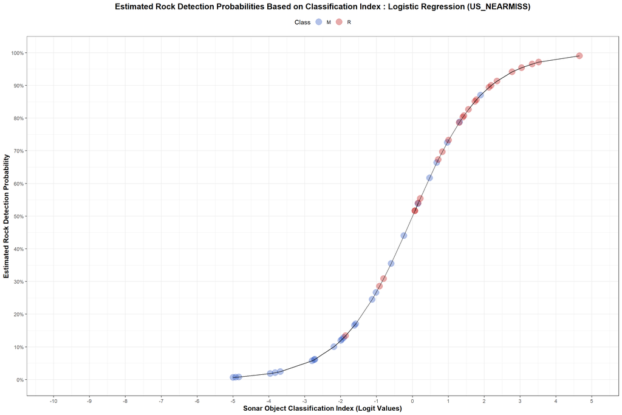

```r
##################################
# Consolidating the model probabilities
# and classification index
# based from the model predictions
##################################
LR_US_NEARMISS_Model_Predictions <- as.data.frame(PMA_PreModelling_Train_LR_US_NEARMISS)
LR_US_NEARMISS_Model_Predictions$LR_US_NEARMISS_Prob <- LR_US_NEARMISS_Model_Probabilities
LR_US_NEARMISS_Model_Predictions$LR_US_NEARMISS_LP <- LR_US_NEARMISS_Model_Indices
LR_US_NEARMISS_Model_Predictions$Class <- as.factor(LR_US_NEARMISS_Model_Predictions$Class)
LR_US_NEARMISS_Model_Predictions$Label <- rep("LR_US_NEARMISS",nrow(LR_US_NEARMISS_Model_Predictions))

##################################
# Formulating the probability curve
# using the consolidated model predictions
##################################
LR_US_NEARMISS_Model_Predictions %>%
  ggplot(aes(x = LR_US_NEARMISS_LP ,
             y = LR_US_NEARMISS_Prob,
             color = Class)) +
  scale_colour_manual(values=c("#1846BA55","#B8000055")) +
  geom_point(size=5) +
  geom_line(color="black") +
  xlab("Sonar Object Classification Index (Logit Values)") +
  ylab("Estimated Rock Detection Probability") +
  labs(color = "Class") +
  scale_x_continuous( limits=c(-10,5), breaks=seq(-10,5,by=1)) +
  scale_y_continuous( limits=c(0,1), breaks=seq(0,1,by=0.1),labels = scales::percent) +
  ggtitle("Estimated Rock Detection Probabilities Based on Classification Index : Logistic Regression (US_NEARMISS)") +
  theme_bw() +
  theme(plot.title = element_text(color="black", size=14, face="bold", hjust=0.50),
        axis.title.x = element_text(color="black", size=12, face="bold"),
        axis.title.y = element_text(color="black", size=12, face="bold"),
        legend.position="top")
```

### 1.5.3 Undersampling - Tomek Links (US_TOMEK)

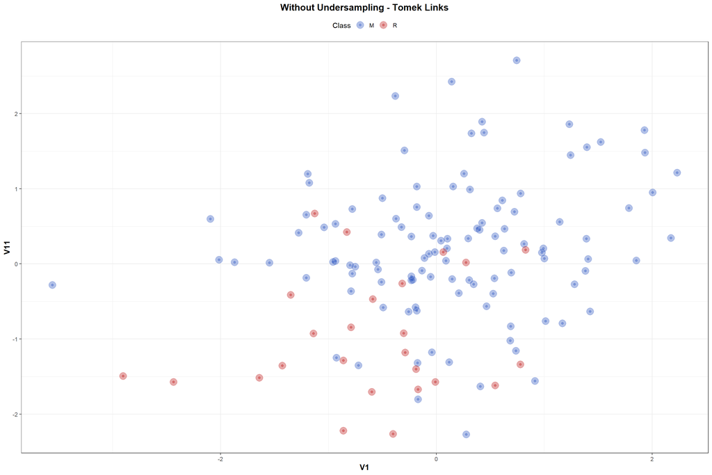

```r
##################################
# Visualizing the imbalanced data set
##################################
ggplot(PMA_PreModelling_Train, aes(V1, V11, color = Class)) +
  geom_point() +
  scale_colour_manual(values=c("#1846BA55","#B8000055")) +
  geom_point(size=5) +
  labs(title = "Without Undersampling - Tomek Links") +
  theme_bw() +
  theme(plot.title = element_text(color="black", size=14, face="bold", hjust=0.50),
        axis.title.x = element_text(color="black", size=12, face="bold"),
        axis.title.y = element_text(color="black", size=12, face="bold"),
        legend.position="top")
```

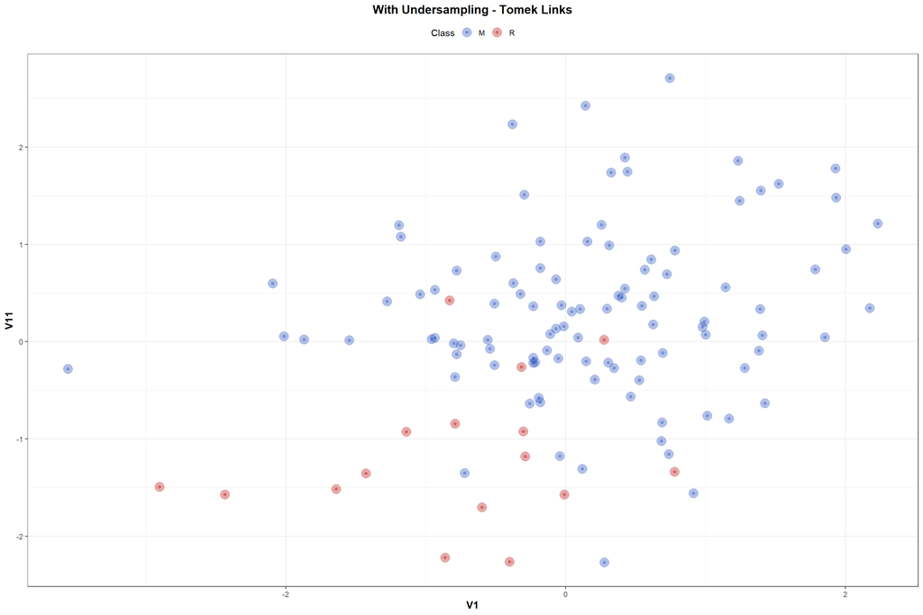

```r
##################################
# Implementing US_TOMEK
# Visualizing the undersampled data using US_TOMEK
##################################
recipe(Class ~ V1 + V11, data = PMA_PreModelling_Train) %>%
  step_tomek(Class, seed=123456789) %>%
  prep() %>%
  bake(new_data = NULL) %>%
  ggplot(aes(V1, V11, color = Class)) +
  geom_point() +
  scale_colour_manual(values=c("#1846BA55","#B8000055")) +
  geom_point(size=5) +
  labs(title = "With Undersampling - Tomek Links") +
  theme_bw() +
  theme(plot.title = element_text(color="black", size=14, face="bold", hjust=0.50),
        axis.title.x = element_text(color="black", size=12, face="bold"),
        axis.title.y = element_text(color="black", size=12, face="bold"),
        legend.position="top")
```

```r
US_TOMEK <- recipe(Class ~ V1 + V11, data = PMA_PreModelling_Train) %>%
  step_tomek(Class, seed=123456789) %>%
  prep()

PMA_PreModelling_Train_LR_US_TOMEK <- US_TOMEK %>%
bake(new_data = NULL)

(PMA_PreModelling_Train_LR_US_TOMEK <- as.data.frame(PMA_PreModelling_Train_LR_US_TOMEK))
```

```
##               V1         V11 Class
## 1    0.914240973 -1.55861587     M
## 2    2.175018299  0.34520609     M
## 3   -0.230553865 -0.16690717     M
## 4    1.231717734  1.85842121     M
## 5    0.424204681  1.89154083     M
## 6    1.143139503  0.55690423     M
## 7   -0.507041623  0.38985083     M
## 8    0.312328639  0.98808941     M
## 9   -0.935159101  0.03686239     M
## 10   0.738227771 -1.15770286     M
## 11   1.169078303 -0.79246144     M
## 12   0.118911997 -1.30982705     M
## 13   1.012209983 -0.76338471     M
## 14   0.207991857 -0.39104999     M
```

[output cut: 104 more lines]

```r
PMA_PreModelling_Train_LR_US_TOMEK$Label <- rep("LR_US_TOMEK",nrow(PMA_PreModelling_Train_LR_US_TOMEK))

##################################
# Verifying the class distribution
# for the undersampled data using US_TOMEK
##################################
table(PMA_PreModelling_Train_LR_US_TOMEK$Class)
```

```
##
##   M   R
## 102  16
```

```r
##################################
# Formulating the structure of the
# Logistic Regression model
##################################
LR_US_TOMEK_Model <- glm(Class ~ V1 + V11,
                data = PMA_PreModelling_Train_LR_US_TOMEK,
                family = binomial)

##################################
# Consolidating the model results
##################################
summary(LR_US_TOMEK_Model)
```

```
##
## Call:
## glm(formula = Class ~ V1 + V11, family = binomial, data = PMA_PreModelling_Train_LR_US_TOMEK)
##
## Deviance Residuals:
##      Min        1Q    Median        3Q       Max
## -1.88129  -0.38305  -0.18048  -0.04904   2.61741
##
## Coefficients:
##             Estimate Std. Error z value Pr(>|z|)
## (Intercept)  -3.1192     0.5681  -5.491 4.00e-08 ***
## V1           -0.8550     0.3663  -2.334   0.0196 *
## V11          -2.1768     0.5199  -4.187 2.83e-05 ***
## ---
## Signif. codes:  0 '***' 0.001 '**' 0.01 '*' 0.05 '.' 0.1 ' ' 1
##
## (Dispersion parameter for binomial family taken to be 1)
##
##     Null deviance: 93.664  on 117  degrees of freedom
## Residual deviance: 51.097  on 115  degrees of freedom
## AIC: 57.097
##
## Number of Fisher Scoring iterations: 7
```

```r
LR_US_TOMEK_Model_Coef <- (as.data.frame(LR_US_TOMEK_Model$coefficients))
LR_US_TOMEK_Model_Coef$Coef <- rownames(LR_US_TOMEK_Model_Coef)
LR_US_TOMEK_Model_Coef$Model <- rep("LR_US_TOMEK",nrow(LR_US_TOMEK_Model_Coef))
colnames(LR_US_TOMEK_Model_Coef) <- c("Estimates","Coefficients","Model")
print(LR_US_TOMEK_Model_Coef, rownames=FALSE)
```

```
##              Estimates Coefficients       Model
## (Intercept) -3.1192250  (Intercept) LR_US_TOMEK
## V1          -0.8549776           V1 LR_US_TOMEK
## V11         -2.1767958          V11 LR_US_TOMEK
```

```r
##################################
# Computing the model predictions
##################################
(LR_US_TOMEK_Model_Probabilities <- predict(LR_US_TOMEK_Model,
                              type = c("response")))
```

```
##            1            2            3            4            5            6
## 3.756409e-01 3.235729e-03 7.183859e-02 2.697569e-04 5.004968e-04 4.923252e-03
##            7            8            9           10           11           12
## 2.835075e-02 3.922375e-03 8.317828e-02 2.261271e-01 8.365176e-02 4.086217e-01
##           13           14           15           16           17           18
## 8.924332e-02 7.974495e-02 8.653858e-02 3.057631e-02 3.401110e-02 6.257509e-02
##           19           20           21           22           23           24
## 1.920963e-02 9.216455e-02 1.033540e-01 2.133670e-02 5.698041e-02 4.151500e-03
##           25           26           27           28           29           30
## 1.152242e-02 4.577910e-04 5.470520e-03 5.412073e-03 4.676720e-04 2.934903e-03
##           31           32           33           34           35           36
## 1.003676e-03 1.902036e-03 3.514870e-04 1.774511e-04 3.379585e-04 6.444174e-05
##           37           38           39           40           41           42
## 4.932868e-02 1.299682e-01 1.632055e-02 1.579461e-02 1.360818e-02 8.296036e-01
##           43           44           45           46           47           48
## 1.142309e-02 8.171200e-03 2.604136e-02 6.468579e-03 1.548320e-01 1.671688e-01
##           49           50           51           52           53           54
## 6.296205e-02 1.024699e-01 3.723887e-01 6.747167e-02 8.003027e-02 3.601015e-02
##           55           56           57           58           59           60
## 1.972224e-02 3.604439e-02 5.183789e-02 5.679248e-02 1.383861e-01 1.002269e-02
##           61           62           63           64           65           66
## 3.952765e-02 1.856837e-01 6.079859e-01 6.305035e-01 1.605248e-01 8.378117e-02
##           67           68           69           70           71           72
## 4.723640e-04 1.615066e-02 1.160016e-02 2.133604e-03 2.606214e-03 6.535624e-04
##           73           74           75           76           77           78
## 2.386204e-02 1.807923e-01 9.227894e-03 7.647569e-04 5.233073e-03 8.953573e-03
##           79           80           81           82           83           84
## 1.145983e-02 2.004250e-04 6.737929e-04 9.896313e-03 1.234693e-02 5.065520e-02
##           85           86           87           88           89           90
## 7.625172e-02 6.398192e-02 5.619436e-02 1.723620e-01 7.788281e-02 1.731500e-02
##           91           92           93           94           95           96
## 8.346450e-02 1.803700e-01 4.061963e-02 3.090759e-02 2.998119e-02 1.724570e-02
##           97           98           99          100          101          102
## 9.337053e-03 4.114982e-03 1.974037e-02 1.132709e-02 1.198585e-02 1.615689e-02
##          103          104          105          106          107          108
## 9.316147e-01 7.509522e-01 4.244291e-01 9.309838e-02 8.291634e-01 3.253605e-02
##          109          110          111          112          113          114
## 9.203724e-01 3.532443e-01 7.409012e-01 2.952220e-01 8.957034e-01 2.996246e-01
##          115          116          117          118
## 3.454790e-02 9.157827e-01 4.681641e-01 5.765988e-01
```

```r
##################################
# Creating a classification index
# based from the model predictions
##################################
(LR_US_TOMEK_Model_Indices <- predict(LR_US_TOMEK_Model,
                           type = c("link")))
```

```
##          1          2          3          4          5          6          7
## -0.5080921 -5.7302601 -2.5587838 -8.2177196 -7.5994087 -5.3088505 -3.5343414
##          8          9         10         11         12         13         14
## -5.5371279 -2.3999268 -1.2303105 -2.3937341 -0.3696661 -2.3229093 -2.4458174
##         15         16         17         18         19         20         21
## -2.3566509 -3.4564762 -3.3464654 -2.7067694 -3.9329471 -2.2874876 -2.1605009
##         22         23         24         25         26         27         28
## -3.8257592 -2.8063796 -5.4801254 -4.4518710 -7.6886399 -5.2028960 -5.2136964
##         29         30         31         32         33         34         35
## -7.6672756 -5.8281418 -6.9030821 -6.2629263 -7.9529862 -8.6366379 -7.9922495
##         36         37         38         39         40         41         42
## -9.6496846 -2.9586628 -1.9012398 -4.0988753 -4.1321657 -4.2833829  1.5828204
##         43         44         45         46         47         48         49
## -4.4606296 -4.7989347 -3.6216827 -5.0343092 -1.6971944 -1.6058269 -2.7001917
##         50         51         52         53         54         55         56
## -2.1700777 -0.5219828 -2.6261917 -2.4419359 -3.2872798 -3.9060890 -3.2862939
##         57         58         59         60         61         62         63
## -2.9064041 -2.8098824 -1.8287596 -4.5928308 -3.1904248 -1.4783039  0.4388540
##         64         65         66         67         68         69         70
##  0.5343773 -1.6543285 -2.3920470 -7.6572883 -4.1095118 -4.4450680 -6.1478070
##         71         72         73         74         75         76         77
## -5.9472473 -7.3324188 -3.7113150 -1.5109890 -4.6762536 -7.1751876 -5.2475099
##         78         79         80         81         82         83         84
## -4.7067087 -4.4573816 -8.5148698 -7.3019137 -4.6056475 -4.3819239 -2.9307301
##         85         86         87         88         89         90         91
## -2.4943996 -2.6830343 -2.8211039 -1.5689790 -2.4714671 -4.0387156 -2.3961794
##         92         93         94         95         96         97         98
## -1.5138426 -3.1620361 -3.4453583 -3.4767452 -4.0427966 -4.6643837 -5.4889973
##         99        100        101        102        103        104        105
## -3.9051518 -4.4691663 -4.4119703 -4.1091196  2.6117614  1.1036970 -0.3046174
##        106        107        108        109        110        111        112
## -2.2763772  1.5797095 -3.3923293  2.4474182 -0.6048087  1.0506577 -0.8701553
##        113        114        115        116        117        118
##  2.1503710 -0.8490861 -3.3302497  2.3863784 -0.1275159  0.3088265
```

```r
max(LR_US_TOMEK_Model_Indices)
```

```
## [1] 2.611761
```

```r
min(LR_US_TOMEK_Model_Indices)
```

```
## [1] -9.649685
```

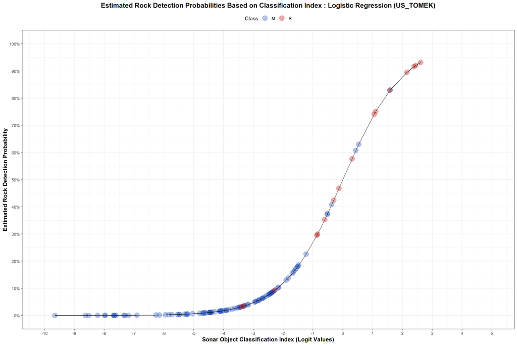

```r
##################################
# Consolidating the model probabilities
# and classification index
# based from the model predictions
##################################
LR_US_TOMEK_Model_Predictions <- as.data.frame(PMA_PreModelling_Train_LR_US_TOMEK)
LR_US_TOMEK_Model_Predictions$LR_US_TOMEK_Prob <- LR_US_TOMEK_Model_Probabilities
LR_US_TOMEK_Model_Predictions$LR_US_TOMEK_LP <- LR_US_TOMEK_Model_Indices
LR_US_TOMEK_Model_Predictions$Class <- as.factor(LR_US_TOMEK_Model_Predictions$Class)
LR_US_TOMEK_Model_Predictions$Label <- rep("LR_US_TOMEK",nrow(LR_US_TOMEK_Model_Predictions))

##################################
# Formulating the probability curve
# using the consolidated model predictions
##################################
LR_US_TOMEK_Model_Predictions %>%
  ggplot(aes(x = LR_US_TOMEK_LP ,
             y = LR_US_TOMEK_Prob,
             color = Class)) +
  scale_colour_manual(values=c("#1846BA55","#B8000055")) +
  geom_point(size=5) +
  geom_line(color="black") +
  xlab("Sonar Object Classification Index (Logit Values)") +
  ylab("Estimated Rock Detection Probability") +
  labs(color = "Class") +
  scale_x_continuous( limits=c(-10,5), breaks=seq(-10,5,by=1)) +
  scale_y_continuous( limits=c(0,1), breaks=seq(0,1,by=0.1),labels = scales::percent) +
  ggtitle("Estimated Rock Detection Probabilities Based on Classification Index : Logistic Regression (US_TOMEK)") +
  theme_bw() +
  theme(plot.title = element_text(color="black", size=14, face="bold", hjust=0.50),
        axis.title.x = element_text(color="black", size=12, face="bold"),
        axis.title.y = element_text(color="black", size=12, face="bold"),
        legend.position="top")
```

### 1.5.4 Oversampling - Adaptive Synthetic Algorithm (OS_ADASYN)

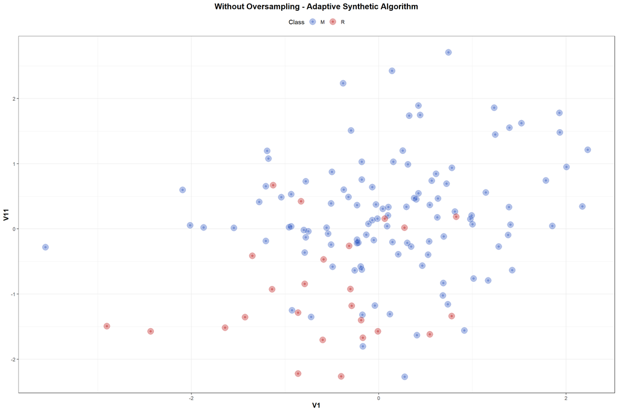

```r
##################################
# Visualizing the imbalanced data set
##################################
ggplot(PMA_PreModelling_Train, aes(V1, V11, color = Class)) +
  geom_point() +
  scale_colour_manual(values=c("#1846BA55","#B8000055")) +
  geom_point(size=5) +
  labs(title = "Without Oversampling - Adaptive Synthetic Algorithm") +
  theme_bw() +
  theme(plot.title = element_text(color="black", size=14, face="bold", hjust=0.50),
        axis.title.x = element_text(color="black", size=12, face="bold"),
        axis.title.y = element_text(color="black", size=12, face="bold"),
        legend.position="top")
```

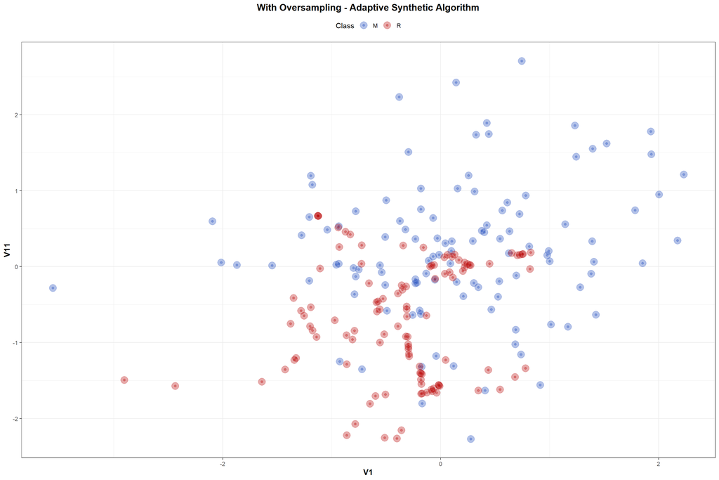

```r
##################################
# Implementing OS_ADASYN
# Visualizing the oversampled data using OS_ADASYN
##################################
recipe(Class ~ V1 + V11, data = PMA_PreModelling_Train) %>%
  step_adasyn(Class, seed=123456789) %>%
  prep() %>%
  bake(new_data = NULL) %>%
  ggplot(aes(V1, V11, color = Class)) +
  geom_point() +
  scale_colour_manual(values=c("#1846BA55","#B8000055")) +
  geom_point(size=5) +
  labs(title = "With Oversampling - Adaptive Synthetic Algorithm") +
  theme_bw() +
  theme(plot.title = element_text(color="black", size=14, face="bold", hjust=0.50),
        axis.title.x = element_text(color="black", size=12, face="bold"),
        axis.title.y = element_text(color="black", size=12, face="bold"),
        legend.position="top")
```

```r
OS_ADASYN <- recipe(Class ~ V1 + V11, data = PMA_PreModelling_Train) %>%
  step_adasyn(Class, seed=123456789) %>%
  prep()

PMA_PreModelling_Train_LR_OS_ADASYN <- OS_ADASYN %>%
bake(new_data = NULL)

(PMA_PreModelling_Train_LR_OS_ADASYN <- as.data.frame(PMA_PreModelling_Train_LR_OS_ADASYN))
```

```
##               V1          V11 Class
## 1    0.914240973 -1.558615871     M
## 2    2.175018299  0.345206089     M
## 3   -0.230553865 -0.166907171     M
## 4    1.231717734  1.858421213     M
## 5    0.424204681  1.891540835     M
## 6    1.143139503  0.556904232     M
## 7   -0.507041623  0.389850825     M
## 8    0.312328639  0.988089406     M
## 9   -0.935159101  0.036862390     M
## 10   0.408807916 -1.630790485     M
## 11   0.738227771 -1.157702863     M
## 12   1.169078303 -0.792461442     M
## 13   0.118911997 -1.309827049     M
## 14  -0.174409184 -1.318776567     M
```

[output cut: 208 more lines]

```r
PMA_PreModelling_Train_LR_OS_ADASYN$Label <- rep("LR_OS_ADASYN",nrow(PMA_PreModelling_Train_LR_OS_ADASYN))

##################################
# Verifying the class distribution
# for the oversampled data using OS_ADASYN
##################################
table(PMA_PreModelling_Train_LR_OS_ADASYN$Class)
```

```
##
##   M   R
## 111 111
```

```r
##################################
# Formulating the structure of the
# Logistic Regression model
##################################
LR_OS_ADASYN_Model <- glm(Class ~ V1 + V11,
                data = PMA_PreModelling_Train_LR_OS_ADASYN,
                family = binomial)

##################################
# Consolidating the model results
##################################
summary(LR_OS_ADASYN_Model)
```

```
##
## Call:
## glm(formula = Class ~ V1 + V11, family = binomial, data = PMA_PreModelling_Train_LR_OS_ADASYN)
##
## Deviance Residuals:
##      Min        1Q    Median        3Q       Max
## -2.19658  -0.90252   0.05818   0.80875   1.68379
##
## Coefficients:
##             Estimate Std. Error z value Pr(>|z|)
## (Intercept)  -0.4101     0.1704  -2.406   0.0161 *
## V1           -0.5944     0.2092  -2.841   0.0045 **
## V11          -1.2753     0.2148  -5.938 2.89e-09 ***
## ---
## Signif. codes:  0 '***' 0.001 '**' 0.01 '*' 0.05 '.' 0.1 ' ' 1
##
## (Dispersion parameter for binomial family taken to be 1)
##
##     Null deviance: 307.76  on 221  degrees of freedom
## Residual deviance: 238.51  on 219  degrees of freedom
## AIC: 244.51
##
## Number of Fisher Scoring iterations: 4
```

```r
LR_OS_ADASYN_Model_Coef <- (as.data.frame(LR_OS_ADASYN_Model$coefficients))
LR_OS_ADASYN_Model_Coef$Coef <- rownames(LR_OS_ADASYN_Model_Coef)
LR_OS_ADASYN_Model_Coef$Model <- rep("LR_OS_ADASYN",nrow(LR_OS_ADASYN_Model_Coef))
colnames(LR_OS_ADASYN_Model_Coef) <- c("Estimates","Coefficients","Model")
print(LR_OS_ADASYN_Model_Coef, rownames=FALSE)
```

```
##              Estimates Coefficients        Model
## (Intercept) -0.4101181  (Intercept) LR_OS_ADASYN
## V1          -0.5943822           V1 LR_OS_ADASYN
## V11         -1.2753114          V11 LR_OS_ADASYN
```

```r
##################################
# Computing the model predictions
##################################
(LR_OS_ADASYN_Model_Probabilities <- predict(LR_OS_ADASYN_Model,
                              type = c("response")))
```

```
##          1          2          3          4          5          6          7
## 0.73772818 0.10497255 0.48494896 0.02896442 0.04416885 0.14187466 0.35298982
##          8          9         10         11         12         13         14
## 0.13518371 0.52465818 0.80638030 0.65192786 0.47642692 0.76667670 0.79825096
##         15         16         17         18         19         20         21
## 0.49045006 0.22563277 0.49124234 0.53149589 0.33788658 0.63266232 0.36893216
##         22         23         24         25         26         27         28
## 0.44577737 0.28975032 0.50841003 0.54957759 0.30403436 0.44012839 0.13580915
##         29         30         31         32         33         34         35
## 0.23425830 0.03850579 0.16603467 0.15576953 0.03615320 0.11201542 0.05655150
##         36         37         38         39         40         41         42
## 0.08175770 0.03278329 0.02139795 0.37136132 0.03089268 0.01331233 0.38955167
##         43         44         45         46         47         48         49
## 0.65126495 0.55947074 0.24727303 0.25025003 0.23441048 0.91040741 0.20957344
##         50         51         52         53         54         55         56
## 0.17258950 0.30485130 0.15948123 0.60850432 0.62090861 0.46015049 0.55448352
##         57         58         59         60         61         62         63
## 0.75312881 0.84972878 0.87949954 0.51859174 0.50205872 0.39855712 0.29561056
##         64         65         66         67         68         69         70
## 0.37370392 0.42217609 0.44608300 0.62022067 0.22674314 0.39134899 0.61942054
##         71         72         73         74         75         76         77
## 0.85093106 0.88724633 0.62758752 0.52149811 0.04594066 0.27777607 0.22716764
##         78         79         80         81         82         83         84
## 0.10369789 0.10997728 0.04766295 0.32399955 0.63553899 0.20078099 0.05642670
##         85         86         87         88         89         90         91
## 0.15127834 0.22638738 0.25274867 0.02699838 0.05205260 0.22027108 0.23133247
##         92         93         94         95         96         97         98
## 0.45499203 0.50158494 0.47436036 0.43346259 0.66212847 0.49743683 0.26750888
##         99        100        101        102        103        104        105
## 0.52203094 0.67231525 0.38096402 0.35437073 0.37001350 0.29351771 0.20504940
##        106        107        108        109        110        111        112
## 0.14025414 0.30145821 0.22508296 0.22092352 0.26547781 0.32450675 0.96153492
##        113        114        115        116        117        118        119
## 0.63113128 0.89281022 0.78004124 0.79069806 0.34357069 0.86087655 0.52828019
##        120        121        122        123        124        125        126
## 0.92386207 0.35531618 0.94938606 0.75708417 0.89718416 0.69734156 0.93788428
##        127        128        129        130        131        132        133
## 0.72074811 0.24230065 0.38787815 0.95448129 0.80984905 0.85057811 0.35536511
##        134        135        136        137        138        139        140
## 0.81543098 0.83188786 0.71492212 0.69470786 0.75211155 0.83042655 0.79922795
```

[output cut: 9 more lines]

```
## 0.35222942 0.25694247 0.34930583 0.35385536 0.25558129 0.37046751 0.61931673
##        176        177        178        179        180        181        182
## 0.93684708 0.90690144 0.94088997 0.78500246 0.72196940 0.76794150 0.87615569
##        183        184        185        186        187        188        189
## 0.87125377 0.77821361 0.75601813 0.74372008 0.84913396 0.85546221 0.73718131
##        190        191        192        193        194        195        196
## 0.75951039 0.62043265 0.74450785 0.60939910 0.26538054 0.45559081 0.32600030
##        197        198        199        200        201        202        203
## 0.42720825 0.26084358 0.38750825 0.29821230 0.49343253 0.56447039 0.41617366
##        204        205        206        207        208        209        210
## 0.35575095 0.56895381 0.34575106 0.35612479 0.37570197 0.45409182 0.38301500
##        211        212        213        214        215        216        217
## 0.81683819 0.81604264 0.83060641 0.84604459 0.88477862 0.79557946 0.74894259
##        218        219        220        221        222
## 0.79681306 0.74388715 0.72730948 0.78620781 0.76129777
```

```r
##################################
# Creating a classification index
# based from the model predictions
##################################
(LR_OS_ADASYN_Model_Indices <- predict(LR_OS_ADASYN_Model,
                           type = c("link")))
```

```
##            1            2            3            4            5            6
##  1.034194007 -2.143155516 -0.060222356 -3.512295020 -3.074561474 -1.799806198
##            7            8            9           10           11           12
## -0.605922800 -1.855882401  0.098712797  1.426659526  0.627524174 -0.094362275
##           13           14           15           16           17           18
##  1.189640156  1.375398467 -0.038204425 -1.233137433 -0.035034220  0.126150588
##           19           20           21           22           23           24
## -0.672726578  0.543655270 -0.536800580 -0.217746823 -0.896596981  0.033643295
##           25           26           27           28           29           30
##  0.198964127 -0.828159573 -0.240641004 -1.850543025 -1.184420539 -3.217679974
##           31           32           33           34           35           36
## -1.613995214 -1.690047948 -3.283166961 -2.070317881 -2.814390118 -2.418701365
##           37           38           39           40           41           42
## -3.384503515 -3.822829815 -0.526381159 -3.445856218 -4.305662512 -0.449197159
##           43           44           45           46           47           48
##  0.624604084  0.239014356 -1.113209442 -1.097279217 -1.183572402  2.318619541
##           49           50           51           52           53           54
## -1.327498549 -1.567384980 -0.824301675 -1.662093081  0.441029528  0.493406603
##           55           56           57           58           59           60
## -0.159736808  0.218802829  1.115369581  1.732475427  1.987699485  0.074401266
##           61           62           63           64           65           66
##  0.008234922 -0.411480728 -0.868288495 -0.516359404 -0.313846676 -0.216509810
##           67           68           69           70           71           72
##  0.490484945 -1.226793467 -0.441645313  0.487089454  1.741922218  2.062917134
##           73           74           75           76           77           78
##  0.521881088  0.086045493 -3.033375348 -0.955519951 -1.224373916 -2.156795762
##           79           80           81           82           83           84
## -2.090973219 -2.994764558 -0.735451606  0.556053884 -1.381420321 -2.816731639
##           85           86           87           88           89           90
## -1.724609805 -1.228823674 -1.084005982 -3.584608772 -2.902044296 -1.264087373
##           91           92           93           94           95           96
## -1.200802614 -0.180520511  0.006339761 -0.102648596 -0.267737627  0.672793868
##           97           98           99          100          101          102
## -0.010252778 -1.007298471  0.088180865  0.718675356 -0.485458441 -0.599881837
##          103          104          105          106          107          108
## -0.532158893 -0.878360151 -1.355029065 -1.813180759 -0.840363591 -1.236286943
##          109          110          111          112          113          114
## -1.260292650 -1.017688967 -0.733136834  3.218780081  0.537073094  2.119773149
##          115          116          117          118          119          120
##  1.265906734  1.329138280 -0.647422117  1.822589419  0.113241617  2.496016154
```

[output cut: 19 more lines]

```
##  0.486649104  2.696961062  2.276375065  2.767425616  1.295060256  0.954251593
##          181          182          183          184          185          186
##  1.196724048  1.956518579  1.912090011  1.255286332  1.130971418  1.065394456
##          187          188          189          190          191          192
##  1.727824656  1.778100926  1.031369484  1.149997104  0.491384999  1.069531722
##          193          194          195          196          197          198
##  0.444787084 -1.018187850 -0.178106078 -0.726331346 -0.293250606 -1.041588666
##          199          200          201          202          203          204
## -0.457798326 -0.855825310 -0.026271400  0.259325140 -0.338500938 -0.593854473
##          205          206          207          208          209          210
##  0.277584017 -0.637768884 -0.592223728 -0.507831661 -0.184151359 -0.476770541
##          211          212          213          214          215          216
##  1.495071084  1.489762635  1.589931142  1.703909032  2.038482188  1.358891395
##          217          218          219          220          221          222
##  1.092980686  1.366493646  1.066271179  0.981014553  1.302216663  1.159807719
```

```r
max(LR_OS_ADASYN_Model_Indices)
```

```
## [1] 3.21878
```

```r
min(LR_OS_ADASYN_Model_Indices)
```

```
## [1] -4.305663
```

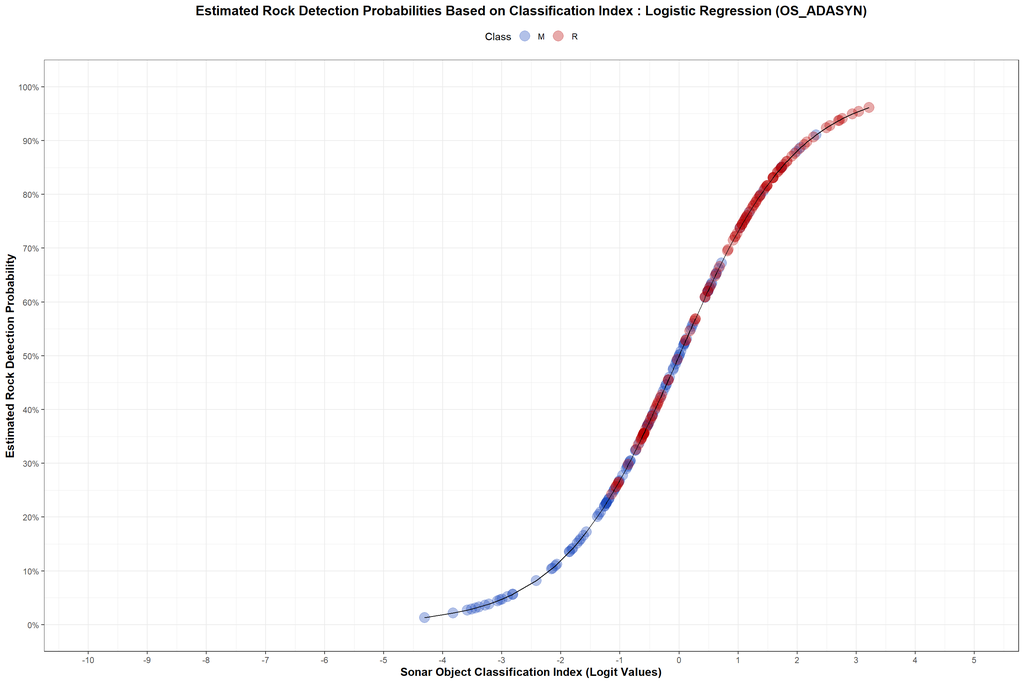

```r
##################################
# Consolidating the model probabilities
# and classification index
# based from the model predictions
##################################
LR_OS_ADASYN_Model_Predictions <- as.data.frame(PMA_PreModelling_Train_LR_OS_ADASYN)
LR_OS_ADASYN_Model_Predictions$LR_OS_ADASYN_Prob <- LR_OS_ADASYN_Model_Probabilities
LR_OS_ADASYN_Model_Predictions$LR_OS_ADASYN_LP <- LR_OS_ADASYN_Model_Indices
LR_OS_ADASYN_Model_Predictions$Class <- as.factor(LR_OS_ADASYN_Model_Predictions$Class)
LR_OS_ADASYN_Model_Predictions$Label <- rep("LR_OS_ADASYN",nrow(LR_OS_ADASYN_Model_Predictions))

##################################
# Formulating the probability curve
# using the consolidated model predictions
##################################
LR_OS_ADASYN_Model_Predictions %>%
  ggplot(aes(x = LR_OS_ADASYN_LP ,
             y = LR_OS_ADASYN_Prob,
             color = Class)) +
  scale_colour_manual(values=c("#1846BA55","#B8000055")) +
  geom_point(size=5) +
  geom_line(color="black") +
  xlab("Sonar Object Classification Index (Logit Values)") +
  ylab("Estimated Rock Detection Probability") +
  labs(color = "Class") +
  scale_x_continuous( limits=c(-10,5), breaks=seq(-10,5,by=1)) +
  scale_y_continuous( limits=c(0,1), breaks=seq(0,1,by=0.1),labels = scales::percent) +
  ggtitle("Estimated Rock Detection Probabilities Based on Classification Index : Logistic Regression (OS_ADASYN)") +
  theme_bw() +
  theme(plot.title = element_text(color="black", size=14, face="bold", hjust=0.50),
        axis.title.x = element_text(color="black", size=12, face="bold"),
        axis.title.y = element_text(color="black", size=12, face="bold"),
        legend.position="top")
```

### 1.5.5 Oversampling - Borderline Synthetic Minority Oversampling Technique (OS_BSMOTE)

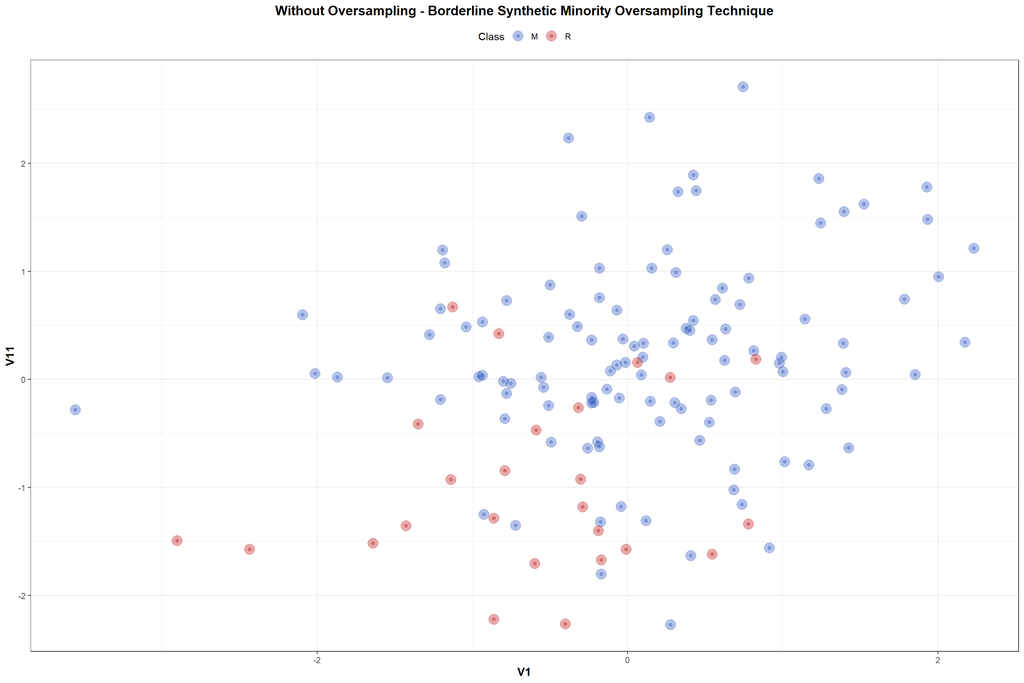

```r
##################################
# Visualizing the imbalanced data set
##################################
ggplot(PMA_PreModelling_Train, aes(V1, V11, color = Class)) +
  geom_point() +
  scale_colour_manual(values=c("#1846BA55","#B8000055")) +
  geom_point(size=5) +
  labs(title = "Without Oversampling - Borderline Synthetic Minority Oversampling Technique") +
  theme_bw() +
  theme(plot.title = element_text(color="black", size=14, face="bold", hjust=0.50),
        axis.title.x = element_text(color="black", size=12, face="bold"),
        axis.title.y = element_text(color="black", size=12, face="bold"),
        legend.position="top")
```

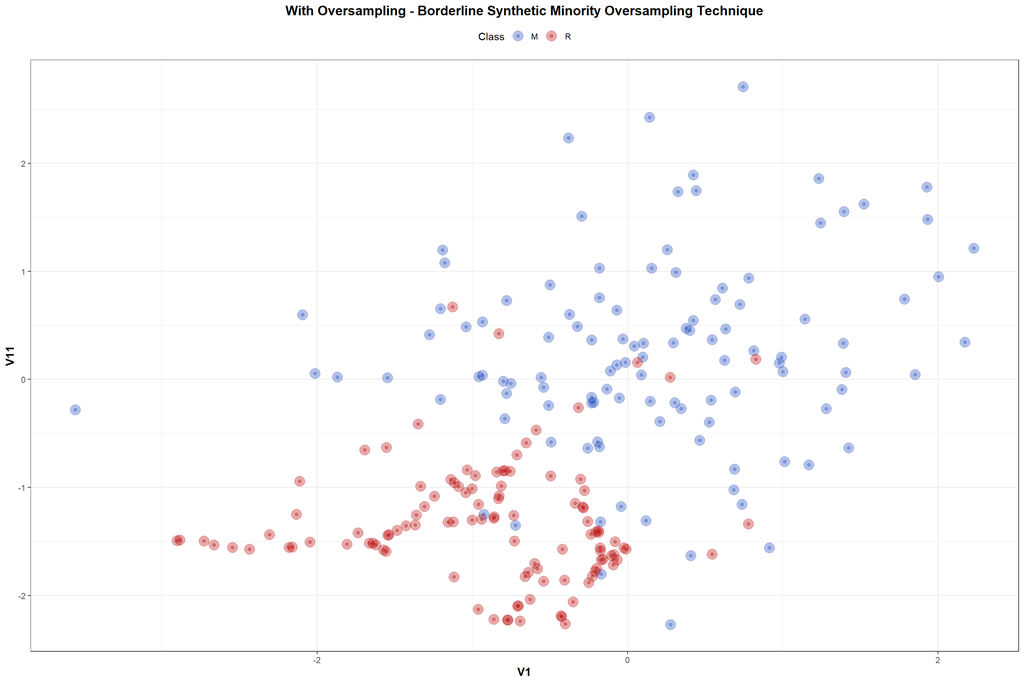

```r
##################################
# Implementing OS_BSMOTE
# Visualizing the oversampled data using OS_BSMOTE
##################################
recipe(Class ~ V1 + V11, data = PMA_PreModelling_Train) %>%
  step_bsmote(Class, seed=123456789) %>%
  prep() %>%
  bake(new_data = NULL) %>%
  ggplot(aes(V1, V11, color = Class)) +
  geom_point() +
  scale_colour_manual(values=c("#1846BA55","#B8000055")) +
  geom_point(size=5) +
  labs(title = "With Oversampling - Borderline Synthetic Minority Oversampling Technique") +
  theme_bw() +
  theme(plot.title = element_text(color="black", size=14, face="bold", hjust=0.50),
        axis.title.x = element_text(color="black", size=12, face="bold"),
        axis.title.y = element_text(color="black", size=12, face="bold"),
        legend.position="top")
```

```r
OS_BSMOTE <- recipe(Class ~ V1 + V11, data = PMA_PreModelling_Train) %>%
  step_bsmote(Class, seed=123456789) %>%
  prep()

PMA_PreModelling_Train_LR_OS_BSMOTE <- OS_BSMOTE %>%
bake(new_data = NULL)

(PMA_PreModelling_Train_LR_OS_BSMOTE <- as.data.frame(PMA_PreModelling_Train_LR_OS_BSMOTE))
```

```
##               V1         V11 Class
## 1    0.914240973 -1.55861587     M
## 2    2.175018299  0.34520609     M
## 3   -0.230553865 -0.16690717     M
## 4    1.231717734  1.85842121     M
## 5    0.424204681  1.89154083     M
## 6    1.143139503  0.55690423     M
## 7   -0.507041623  0.38985083     M
## 8    0.312328639  0.98808941     M
## 9   -0.935159101  0.03686239     M
## 10   0.408807916 -1.63079048     M
## 11   0.738227771 -1.15770286     M
## 12   1.169078303 -0.79246144     M
## 13   0.118911997 -1.30982705     M
## 14  -0.174409184 -1.31877657     M
```

[output cut: 208 more lines]

```r
PMA_PreModelling_Train_LR_OS_BSMOTE$Label <- rep("LR_OS_BSMOTE",nrow(PMA_PreModelling_Train_LR_OS_BSMOTE))

##################################
# Verifying the class distribution
# for the oversampled data using OS_BSMOTE
##################################
table(PMA_PreModelling_Train_LR_OS_BSMOTE$Class)
```

```
##
##   M   R
## 111 111
```

```r
##################################
# Formulating the structure of the
# Logistic Regression model
##################################
LR_OS_BSMOTE_Model <- glm(Class ~ V1 + V11,
                data = PMA_PreModelling_Train_LR_OS_BSMOTE,
                family = binomial)

##################################
# Consolidating the model results
##################################
summary(LR_OS_BSMOTE_Model)
```

```
##
## Call:
## glm(formula = Class ~ V1 + V11, family = binomial, data = PMA_PreModelling_Train_LR_OS_BSMOTE)
##
## Deviance Residuals:
##      Min        1Q    Median        3Q       Max
## -2.51118  -0.31186   0.04469   0.46486   2.82180
##
## Coefficients:
##             Estimate Std. Error z value Pr(>|z|)
## (Intercept)  -2.3748     0.4136  -5.742 9.36e-09 ***
## V1           -1.3384     0.3235  -4.138 3.50e-05 ***
## V11          -2.5707     0.3536  -7.271 3.58e-13 ***
## ---
## Signif. codes:  0 '***' 0.001 '**' 0.01 '*' 0.05 '.' 0.1 ' ' 1
##
## (Dispersion parameter for binomial family taken to be 1)
##
##     Null deviance: 307.76  on 221  degrees of freedom
## Residual deviance: 126.59  on 219  degrees of freedom
## AIC: 132.59
##
## Number of Fisher Scoring iterations: 6
```

```r
LR_OS_BSMOTE_Model_Coef <- (as.data.frame(LR_OS_BSMOTE_Model$coefficients))
LR_OS_BSMOTE_Model_Coef$Coef <- rownames(LR_OS_BSMOTE_Model_Coef)
LR_OS_BSMOTE_Model_Coef$Model <- rep("LR_OS_BSMOTE",nrow(LR_OS_BSMOTE_Model_Coef))
colnames(LR_OS_BSMOTE_Model_Coef) <- c("Estimates","Coefficients","Model")
print(LR_OS_BSMOTE_Model_Coef, rownames=FALSE)
```

```
##             Estimates Coefficients        Model
## (Intercept) -2.374787  (Intercept) LR_OS_BSMOTE
## V1          -1.338444           V1 LR_OS_BSMOTE
## V11         -2.570724          V11 LR_OS_BSMOTE
```

```r
##################################
# Computing the model predictions
##################################
(LR_OS_BSMOTE_Model_Probabilities <- predict(LR_OS_BSMOTE_Model,
                              type = c("response")))
```

```
##            1            2            3            4            5            6
## 6.006859e-01 2.079892e-03 1.628557e-01 1.505806e-04 4.074472e-04 4.789811e-03
##            7            8            9           10           11           12
## 6.307140e-02 4.806695e-03 2.283076e-01 7.808042e-01 4.045050e-01 1.298446e-01
##           13           14           15           16           17           18
## 6.970438e-01 7.771026e-01 1.459006e-01 1.555055e-02 1.613942e-01 2.387661e-01
##           19           20           21           22           23           24
## 4.734715e-02 4.296759e-01 6.783271e-02 1.129486e-01 3.324495e-02 1.757225e-01
##           25           26           27           28           29           30
## 2.542867e-01 3.828633e-02 1.136601e-01 4.659037e-03 1.934256e-02 2.664560e-04
##           31           32           33           34           35           36
## 8.357633e-03 6.469618e-03 2.077176e-04 2.926166e-03 5.513619e-04 1.261781e-03
##           37           38           39           40           41           42
## 1.869932e-04 7.303152e-05 8.016464e-02 1.560020e-04 3.258266e-05 6.577898e-02
##           43           44           45           46           47           48
## 4.451968e-01 2.381189e-01 1.823696e-02 1.982859e-02 1.677255e-02 9.563376e-01
##           49           50           51           52           53           54
## 1.187490e-02 6.912386e-03 3.262472e-02 6.098557e-03 3.470533e-01 3.709446e-01
##           55           56           57           58           59           60
## 1.343831e-01 2.693959e-01 6.695195e-01 8.883345e-01 9.228887e-01 2.489130e-01
##           61           62           63           64           65           66
## 1.825541e-01 9.693127e-02 3.577391e-02 6.904229e-02 9.767097e-02 1.228251e-01
##           67           68           69           70           71           72
## 4.152266e-01 1.887292e-02 8.143187e-02 3.401731e-01 8.874048e-01 9.572771e-01
##           73           74           75           76           77           78
## 4.048304e-01 2.193652e-01 4.954973e-04 3.161516e-02 1.675101e-02 2.859779e-03
##           79           80           81           82           83           84
## 3.021328e-03 4.265516e-04 4.750576e-02 4.034164e-01 1.187473e-02 6.945722e-04
##           85           86           87           88           89           90
## 5.905442e-03 2.067431e-02 2.743980e-02 1.516378e-04 5.752660e-04 1.677652e-02
##           91           92           93           94           95           96
## 1.720777e-02 1.501903e-01 1.885182e-01 1.574837e-01 1.056248e-01 5.175650e-01
##           97           98           99          100          101          102
## 1.767992e-01 2.493234e-02 2.212795e-01 5.456617e-01 6.900384e-02 5.978552e-02
##          103          104          105          106          107          108
## 7.659193e-02 3.881689e-02 1.288117e-02 5.351133e-03 3.928910e-02 1.641340e-02
##          109          110          111          112          113          114
## 1.437443e-02 2.555662e-02 4.565748e-02 9.952622e-01 4.054342e-01 9.431421e-01
##          115          116          117          118          119          120
## 7.396726e-01 7.416806e-01 5.405582e-02 8.956161e-01 2.183267e-01 9.761822e-01
```

[output cut: 19 more lines]

```
## 5.925718e-01 6.947628e-01 7.228503e-01 6.418228e-01 8.291525e-01 5.022260e-01
##          181          182          183          184          185          186
## 9.289512e-01 9.250913e-01 8.880508e-01 9.011649e-01 9.488224e-01 9.676439e-01
##          187          188          189          190          191          192
## 8.279311e-01 9.877165e-01 9.315634e-01 9.672930e-01 9.865775e-01 9.423702e-01
##          193          194          195          196          197          198
## 8.820166e-01 8.963778e-01 9.735002e-01 9.941401e-01 9.770490e-01 9.890819e-01
##          199          200          201          202          203          204
## 9.879220e-01 7.894770e-01 9.757711e-01 9.171668e-01 8.680804e-01 7.062853e-01
##          205          206          207          208          209          210
## 9.356769e-01 7.727403e-01 7.616280e-01 8.290050e-01 8.637211e-01 9.096805e-01
##          211          212          213          214          215          216
## 8.858527e-01 8.480944e-01 8.188099e-01 7.761464e-01 8.363531e-01 8.206201e-01
##          217          218          219          220          221          222
## 9.025137e-01 8.313514e-01 8.403899e-01 7.438513e-01 8.732280e-01 6.545208e-01
```

```r
##################################
# Creating a classification index
# based from the model predictions
##################################
(LR_OS_BSMOTE_Model_Indices <- predict(LR_OS_BSMOTE_Model,
                           type = c("link")))
```

```
##             1             2             3             4             5
##   0.408324003  -6.173357428  -1.637131633  -8.800861401  -7.805191778
##             6             7             8             9            10
##  -5.336462967  -2.698339590  -5.332927345  -1.217892324   1.270358909
##            11            12            13            14            15
##  -0.386729015  -1.902333371   0.833259849   1.248860586  -1.767122159
##            16            17            18            19            20
##  -4.147986246  -1.647891134  -1.159456434  -3.001743931  -0.283173443
##            21            22            23            24            25
##  -2.620467808  -2.060969930  -3.370042340  -1.545601145  -1.075879089
##            26            27            28            29            30
##  -3.223623920  -2.053888243  -5.364276686  -3.925915527  -8.230035045
##            31            32            33            34            35
##  -4.776187215  -5.034147554  -8.479123183  -5.831131646  -7.502567613
##            36            37            38            39            40
##  -6.673968501  -8.584251291  -9.524546462  -2.440112242  -8.765485802
##            41            42            43            44            45
## -10.331697835  -2.653412674  -0.220096954  -1.163020255  -3.985899663
##            46            47            48            49            50
##  -3.900602432  -4.071096916   3.086623816  -4.421382008  -4.967504071
##            51            52            53            54            55
##  -3.389516181  -5.093585877  -0.632017084  -0.528166665  -1.862747933
##            56            57            58            59            60
##  -0.997689924   0.706012696   2.073840593   2.482259349  -1.104418259
##            61            62            63            64            65
##  -1.499138052  -2.231796468  -3.294107073  -2.601494709  -2.223374824
##            66            67            68            69            70
##  -1.965944774  -0.342400130  -3.950973850  -2.423049316  -0.662522844
##            71            72            73            74            75
##   2.064502155   3.109357894  -0.385378145  -1.269369274  -7.609452965
##            76            77            78            79            80
##  -3.421992894  -4.072403649  -5.854146889  -5.799032924  -7.759350558
##            81            82            83            84            85
##  -2.998233112  -0.391250280  -4.421396791  -7.271519668  -5.125957993
##            86            87            88            89            90
##  -3.857972335  -3.567937550  -8.793864147  -7.460102633  -4.070856278
##            91            92            93            94            95
##  -4.045036769  -1.733109397  -1.459667592  -1.677071125  -2.136231934
##            96            97            98            99           100
##   0.070289110  -1.538185522  -3.666340925  -1.258225807   0.183156955
```

[output cut: 35 more lines]

```
##   3.398060745   1.571035089   4.387137173   2.610956908   3.386912469
##           191           192           193           194           195
##   4.297309508   2.794358127   2.011667419   2.157609899   3.603760225
##           196           197           198           199           200
##   5.133737324   3.751174055   4.506352641   4.404218553   1.321775934
##           201           202           203           204           205
##   3.695683464   2.404459967   1.884091524   0.877410183   2.677351471
##           206           207           208           209           210
##   1.223849729   1.161625750   1.578591698   1.846546094   2.309739633
##           211           212           213           214           215
##   2.049061392   1.719732291   1.508305278   1.243348656   1.631339559
##           216           217           218           219           220
##   1.520554047   2.225472173   1.595235372   1.661131855   1.066083204
##           221           222
##   1.929806883   0.638970888
```

```r
max(LR_OS_BSMOTE_Model_Indices)
```

```
## [1] 5.347433
```

```r
min(LR_OS_BSMOTE_Model_Indices)
```

```
## [1] -10.3317
```

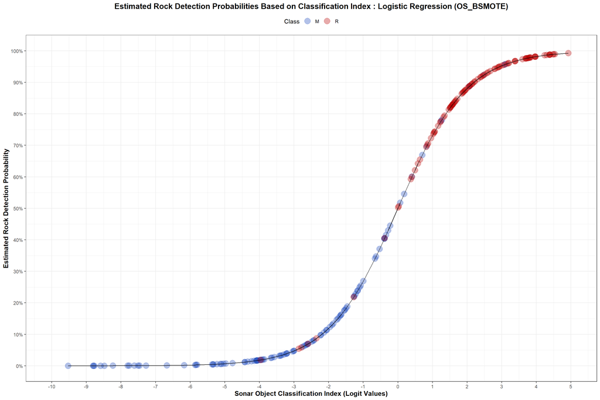

```r
##################################
# Consolidating the model probabilities
# and classification index
# based from the model predictions
##################################
LR_OS_BSMOTE_Model_Predictions <- as.data.frame(PMA_PreModelling_Train_LR_OS_BSMOTE)
LR_OS_BSMOTE_Model_Predictions$LR_OS_BSMOTE_Prob <- LR_OS_BSMOTE_Model_Probabilities
LR_OS_BSMOTE_Model_Predictions$LR_OS_BSMOTE_LP <- LR_OS_BSMOTE_Model_Indices
LR_OS_BSMOTE_Model_Predictions$Class <- as.factor(LR_OS_BSMOTE_Model_Predictions$Class)
LR_OS_BSMOTE_Model_Predictions$Label <- rep("LR_OS_BSMOTE",nrow(LR_OS_BSMOTE_Model_Predictions))

##################################
# Formulating the probability curve
# using the consolidated model predictions
##################################
LR_OS_BSMOTE_Model_Predictions %>%
  ggplot(aes(x = LR_OS_BSMOTE_LP ,
             y = LR_OS_BSMOTE_Prob,
             color = Class)) +
  scale_colour_manual(values=c("#1846BA55","#B8000055")) +
  geom_point(size=5) +
  geom_line(color="black") +
  xlab("Sonar Object Classification Index (Logit Values)") +
  ylab("Estimated Rock Detection Probability") +
  labs(color = "Class") +
  scale_x_continuous( limits=c(-10,5), breaks=seq(-10,5,by=1)) +
  scale_y_continuous( limits=c(0,1), breaks=seq(0,1,by=0.1),labels = scales::percent) +
  ggtitle("Estimated Rock Detection Probabilities Based on Classification Index : Logistic Regression (OS_BSMOTE)") +
  theme_bw() +
  theme(plot.title = element_text(color="black", size=14, face="bold", hjust=0.50),
        axis.title.x = element_text(color="black", size=12, face="bold"),
        axis.title.y = element_text(color="black", size=12, face="bold"),
        legend.position="top")
```

### 1.5.6 Oversampling - Synthetic Minority Oversampling Technique (OS_SMOTE)

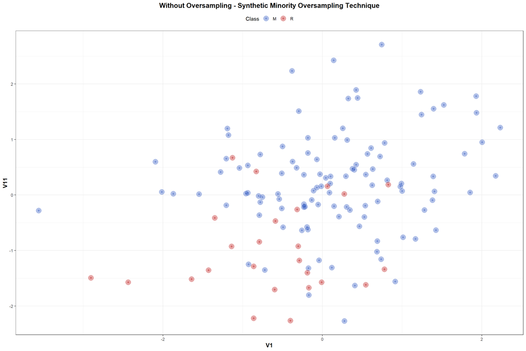

```r
##################################
# Visualizing the imbalanced data set
##################################
ggplot(PMA_PreModelling_Train, aes(V1, V11, color = Class)) +
  geom_point() +
  scale_colour_manual(values=c("#1846BA55","#B8000055")) +
  geom_point(size=5) +
  labs(title = "Without Oversampling - Synthetic Minority Oversampling Technique") +
  theme_bw() +
  theme(plot.title = element_text(color="black", size=14, face="bold", hjust=0.50),
        axis.title.x = element_text(color="black", size=12, face="bold"),
        axis.title.y = element_text(color="black", size=12, face="bold"),
        legend.position="top")
```

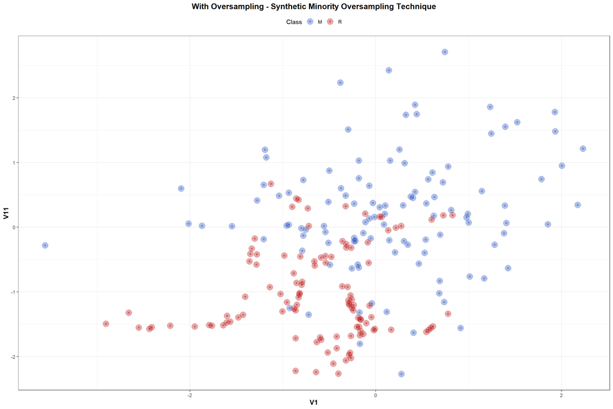

```r
##################################
# Implementing OS_SMOTE
# Visualizing the oversampled data using OS_SMOTE
##################################
recipe(Class ~ V1 + V11, data = PMA_PreModelling_Train) %>%
  step_smote(Class, seed=123456789) %>%
  prep() %>%
  bake(new_data = NULL) %>%
  ggplot(aes(V1, V11, color = Class)) +
  geom_point() +
  scale_colour_manual(values=c("#1846BA55","#B8000055")) +
  geom_point(size=5) +
  labs(title = "With Oversampling - Synthetic Minority Oversampling Technique") +
  theme_bw() +
  theme(plot.title = element_text(color="black", size=14, face="bold", hjust=0.50),
        axis.title.x = element_text(color="black", size=12, face="bold"),
        axis.title.y = element_text(color="black", size=12, face="bold"),
        legend.position="top")
```

```r
OS_SMOTE <- recipe(Class ~ V1 + V11, data = PMA_PreModelling_Train) %>%
  step_smote(Class, seed=123456789) %>%
  prep()

PMA_PreModelling_Train_LR_OS_SMOTE <- OS_SMOTE %>%
bake(new_data = NULL)

(PMA_PreModelling_Train_LR_OS_SMOTE <- as.data.frame(PMA_PreModelling_Train_LR_OS_SMOTE))
```

```
##               V1          V11 Class
## 1    0.914240973 -1.558615871     M
## 2    2.175018299  0.345206089     M
## 3   -0.230553865 -0.166907171     M
## 4    1.231717734  1.858421213     M
## 5    0.424204681  1.891540835     M
## 6    1.143139503  0.556904232     M
## 7   -0.507041623  0.389850825     M
## 8    0.312328639  0.988089406     M
## 9   -0.935159101  0.036862390     M
## 10   0.408807916 -1.630790485     M
## 11   0.738227771 -1.157702863     M
## 12   1.169078303 -0.792461442     M
## 13   0.118911997 -1.309827049     M
## 14  -0.174409184 -1.318776567     M
```

[output cut: 208 more lines]

```r
PMA_PreModelling_Train_LR_OS_SMOTE$Label <- rep("LR_OS_SMOTE",nrow(PMA_PreModelling_Train_LR_OS_SMOTE))

##################################
# Verifying the class distribution
# for the oversampled data using OS_SMOTE
##################################
table(PMA_PreModelling_Train_LR_OS_SMOTE$Class)
```

```
##
##   M   R
## 111 111
```

```r
##################################
# Formulating the structure of the
# Logistic Regression model
##################################
LR_OS_SMOTE_Model <- glm(Class ~ V1 + V11,
                data = PMA_PreModelling_Train_LR_OS_SMOTE,
                family = binomial)

##################################
# Consolidating the model results
##################################
summary(LR_OS_SMOTE_Model)
```

```
##
## Call:
## glm(formula = Class ~ V1 + V11, family = binomial, data = PMA_PreModelling_Train_LR_OS_SMOTE)
##
## Deviance Residuals:
##      Min        1Q    Median        3Q       Max
## -2.37841  -0.64478   0.05535   0.65629   2.12157
##
## Coefficients:
##             Estimate Std. Error z value Pr(>|z|)
## (Intercept)  -1.0415     0.2324  -4.481 7.43e-06 ***
## V1           -0.9329     0.2481  -3.760  0.00017 ***
## V11          -1.7443     0.2506  -6.961 3.38e-12 ***
## ---
## Signif. codes:  0 '***' 0.001 '**' 0.01 '*' 0.05 '.' 0.1 ' ' 1
##
## (Dispersion parameter for binomial family taken to be 1)
##
##     Null deviance: 307.76  on 221  degrees of freedom
## Residual deviance: 189.34  on 219  degrees of freedom
## AIC: 195.34
##
## Number of Fisher Scoring iterations: 5
```

```r
LR_OS_SMOTE_Model_Coef <- (as.data.frame(LR_OS_SMOTE_Model$coefficients))
LR_OS_SMOTE_Model_Coef$Coef <- rownames(LR_OS_SMOTE_Model_Coef)
LR_OS_SMOTE_Model_Coef$Model <- rep("LR_OS_SMOTE",nrow(LR_OS_SMOTE_Model_Coef))
colnames(LR_OS_SMOTE_Model_Coef) <- c("Estimates","Coefficients","Model")
print(LR_OS_SMOTE_Model_Coef, rownames=FALSE)
```

```
##              Estimates Coefficients       Model
## (Intercept) -1.0415029  (Intercept) LR_OS_SMOTE
## V1          -0.9328753           V1 LR_OS_SMOTE
## V11         -1.7442581          V11 LR_OS_SMOTE
```

```r
##################################
# Computing the model predictions
##################################
(LR_OS_SMOTE_Model_Probabilities <- predict(LR_OS_SMOTE_Model,
                              type = c("response")))
```

```
##           1           2           3           4           5           6
## 0.695138300 0.024779368 0.369282594 0.004354817 0.008692463 0.043969471
##           7           8           9          10          11          12
## 0.222960465 0.044944135 0.441910102 0.805596919 0.571789299 0.320853998
##          13          14          15          16          17          18
## 0.756252682 0.805571240 0.342037247 0.094083981 0.365066375 0.451846444
##          19          20          21          22          23          24
## 0.184808902 0.600480342 0.230322198 0.301195793 0.151952308 0.379797538
##          25          26          27          28          29          30
## 0.463155988 0.165407411 0.304190208 0.043728465 0.109852360 0.006375734
##          31          32          33          34          35          36
## 0.064984856 0.054172728 0.005280164 0.032108175 0.010248414 0.017939314
##          37          38          39          40          41          42
## 0.005004700 0.002624183 0.258068057 0.004383673 0.001564322 0.219981147
##          43          44          45          46          47          48
## 0.606499788 0.441184242 0.102585458 0.108944043 0.098265568 0.934454823
##          49          50          51          52          53          54
## 0.078354180 0.054862637 0.146577492 0.051143629 0.536373281 0.553768583
##          55          56          57          58          59          60
## 0.333413190 0.478049348 0.740748894 0.880774271 0.905356078 0.468097562
##          61          62          63          64          65          66
## 0.391344086 0.285203257 0.159156007 0.231913539 0.279632581 0.318466956
##          67          68          69          70          71          72
## 0.592843463 0.109231538 0.255107619 0.525804921 0.879578471 0.940894174
##          73          74          75          76          77          78
## 0.581234332 0.432191970 0.010111774 0.148952395 0.099457455 0.032453398
##          79          80          81          82          83          84
## 0.033206650 0.008786310 0.188648708 0.577051822 0.079747910 0.012468425
##          85          86          87          88          89          90
## 0.050879338 0.117284577 0.139201194 0.004494323 0.010955560 0.100848196
##          91          92          93          94          95          96
## 0.100810641 0.360177402 0.399570525 0.364853162 0.291485499 0.660093722
##          97          98          99         100         101         102
## 0.384977539 0.126385323 0.434344509 0.677845021 0.229873159 0.214271334
##         103         104         105         106         107         108
## 0.250440555 0.169600465 0.084343448 0.048368075 0.169214359 0.098258011
##         109         110         111         112         113         114
## 0.089207115 0.129213957 0.183140465 0.986209131 0.580441619 0.923457474
##         115         116         117         118         119         120
## 0.783385955 0.781081414 0.202008970 0.884155454 0.428550245 0.958104757
```

[output cut: 19 more lines]

```
## 0.835253446 0.646610366 0.863408362 0.897122923 0.940823077 0.847511773
##         181         182         183         184         185         186
## 0.950828270 0.806493833 0.756862021 0.741953895 0.935087595 0.852792408
##         187         188         189         190         191         192
## 0.939045080 0.708868092 0.769362054 0.741347551 0.781704288 0.365380305
##         193         194         195         196         197         198
## 0.559671314 0.439870312 0.401274633 0.296039750 0.265373614 0.975340798
##         199         200         201         202         203         204
## 0.982814940 0.980179251 0.867214606 0.736213169 0.761511998 0.777944845
##         205         206         207         208         209         210
## 0.878213438 0.822334132 0.817719367 0.685821378 0.417713421 0.213421318
##         211         212         213         214         215         216
## 0.617722703 0.831278762 0.798876785 0.859120974 0.758566641 0.871250176
##         217         218         219         220         221         222
## 0.831039532 0.837447101 0.759607794 0.320505259 0.707218982 0.894816419
```

```r
##################################
# Creating a classification index
# based from the model predictions
##################################
(LR_OS_SMOTE_Model_Indices <- predict(LR_OS_SMOTE_Model,
                           type = c("link")))
```

```
##           1           2           3           4           5           6
##  0.82425259 -3.67265237 -0.53529572 -5.43210828 -4.73656844 -3.07929429
##           7           8           9          10          11          12
## -1.24849676 -3.05634956 -0.23341359  1.42164977  0.28915520 -0.74984995
##          13          14          15          16          17          18
##  1.13224345  1.42148582 -0.65422868 -2.26475881 -0.55344128 -0.19321306
##          19          20          21          22          23          24
## -1.48410023  0.40746693 -1.20649280 -0.84161007 -1.71937016 -0.49040766
##          25          26          27          28          29          30
## -0.14764367 -1.61853210 -0.82742315 -3.08504263 -2.09225005 -5.04885991
##          31          32          33          34          35          36
## -2.66640847 -2.85988236 -5.23850398 -3.40600965 -4.57033103 -4.00265851
##          37          38          39          40          41          42
## -5.29236048 -5.94035796 -1.05603418 -5.42547492 -6.45873755 -1.26577624
##          43          44          45          46          47          48
##  0.43262277 -0.23635725 -2.16882171 -2.10157285 -2.21664637  2.65722365
##          49          50          51          52          53          54
## -2.46492169 -2.84649772 -1.76170050 -2.92061950  0.14575059  0.21590919
##          55          56          57          58          59          60
## -0.69278785 -0.08785908  1.04986458  1.99978279  2.25820667 -0.12778335
##          61          62          63          64          65          66
## -0.44166592 -0.91879612 -1.66452124 -1.19753768 -0.94628485 -0.76082602
##          67          68          69          70          71          72
##  0.37573267 -2.09861470 -1.07155426  0.10331148  1.98844445  2.76750117
##          73          74          75          76          77          78
##  0.32784250 -0.27291352 -4.58389159 -1.74284131 -2.20326744 -3.39495845
##          79          80          81          82          83          84
## -3.37123462 -4.72573535 -1.45881452  0.31068241 -2.44577712 -4.37200900
##          85          86          87          88          89          90
## -2.92607903 -2.01839960 -1.82194048 -5.40043585 -4.50289216 -2.18783550
##          91          92          93          94          95          96
## -2.18824973 -0.57459425 -0.40725491 -0.55436124 -0.88818027  0.66371190
##          97          98          99         100         101         102
## -0.46847380 -1.93330405 -0.26414720  0.74388595 -1.20902755 -1.29936840
##         103         104         105         106         107         108
## -1.09626404 -1.58846149 -2.38474422 -2.97933833 -1.59120550 -2.21673166
##         109         110         111         112         113         114
## -2.32335472 -1.90792669 -1.49521373  4.26986170  0.32458654  2.49027827
##         115         116         117         118         119         120
##  1.28550832  1.27197948 -1.37378525  2.03238373 -0.28776857  3.12978483
```

[output cut: 19 more lines]

```
##  1.62332695  0.60417267  1.84389204  2.16565804  2.76622345  1.71521733
##         181         182         183         184         185         186
##  2.96201461  1.42738687  1.13555187  1.05614883  2.66760147  1.75667237
##         187         188         189         190         191         192
##  2.73472891  0.88989300  1.20471252  1.05298428  1.27562590 -0.55208717
##         193         194         195         196         197         198
##  0.23982821 -0.24168840 -0.40015694 -0.86622815 -1.01822335  3.67763681
##         199         200         201         202         203         204
##  4.04638045  3.90100613  1.87655223  1.02637839  1.16098692  1.25372983
##         205         206         207         208         209         210
##  1.97561964  1.53224216  1.50097177  0.78065553 -0.33216713 -1.30442453
##         211         212         213         214         215         216
##  0.47989340  1.59471732  1.37928899  1.80800819  1.14483716  1.91205799
##         217         218         219         220         221         222
##  1.59301260  1.63935462  1.15053046 -0.75145081  0.88191540  2.14091136
```

```r
max(LR_OS_SMOTE_Model_Indices)
```

```
## [1] 4.269862
```

```r
min(LR_OS_SMOTE_Model_Indices)
```

```
## [1] -6.458738
```

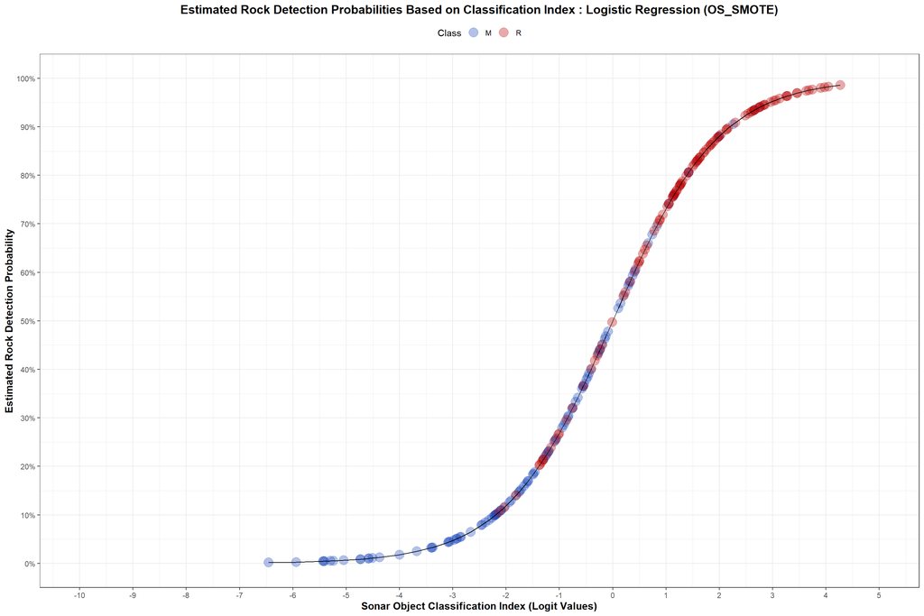

```r
##################################
# Consolidating the model probabilities
# and classification index
# based from the model predictions
##################################
LR_OS_SMOTE_Model_Predictions <- as.data.frame(PMA_PreModelling_Train_LR_OS_SMOTE)
LR_OS_SMOTE_Model_Predictions$LR_OS_SMOTE_Prob <- LR_OS_SMOTE_Model_Probabilities
LR_OS_SMOTE_Model_Predictions$LR_OS_SMOTE_LP <- LR_OS_SMOTE_Model_Indices
LR_OS_SMOTE_Model_Predictions$Class <- as.factor(LR_OS_SMOTE_Model_Predictions$Class)
LR_OS_SMOTE_Model_Predictions$Label <- rep("LR_OS_SMOTE",nrow(LR_OS_SMOTE_Model_Predictions))

##################################
# Formulating the probability curve
# using the consolidated model predictions
##################################
LR_OS_SMOTE_Model_Predictions %>%
  ggplot(aes(x = LR_OS_SMOTE_LP ,
             y = LR_OS_SMOTE_Prob,
             color = Class)) +
  scale_colour_manual(values=c("#1846BA55","#B8000055")) +
  geom_point(size=5) +
  geom_line(color="black") +
  xlab("Sonar Object Classification Index (Logit Values)") +
  ylab("Estimated Rock Detection Probability") +
  labs(color = "Class") +
  scale_x_continuous( limits=c(-10,5), breaks=seq(-10,5,by=1)) +
  scale_y_continuous( limits=c(0,1), breaks=seq(0,1,by=0.1),labels = scales::percent) +
  ggtitle("Estimated Rock Detection Probabilities Based on Classification Index : Logistic Regression (OS_SMOTE)") +
  theme_bw() +
  theme(plot.title = element_text(color="black", size=14, face="bold", hjust=0.50),
        axis.title.x = element_text(color="black", size=12, face="bold"),
        axis.title.y = element_text(color="black", size=12, face="bold"),
        legend.position="top")
```

### 1.5.7 Oversampling - Random Oversampling Examples (OS_ROSE)

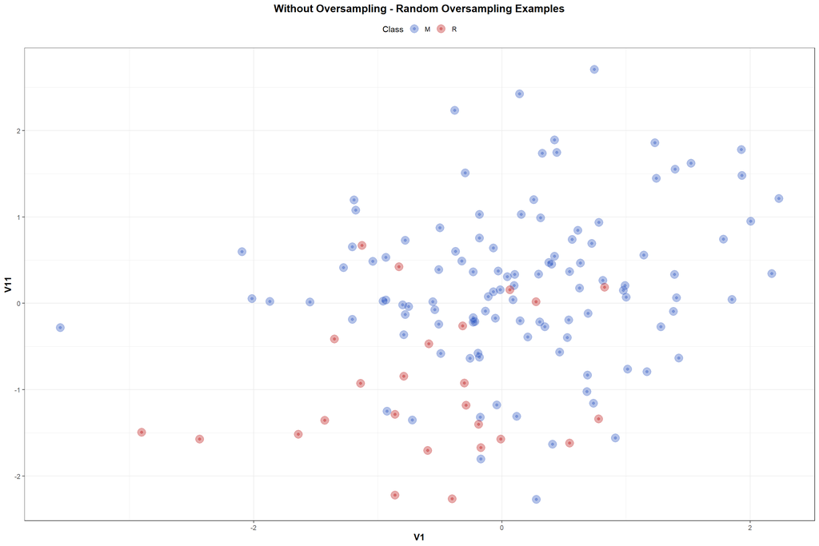

```r
##################################
# Visualizing the imbalanced data set
##################################
ggplot(PMA_PreModelling_Train, aes(V1, V11, color = Class)) +
  geom_point() +
  scale_colour_manual(values=c("#1846BA55","#B8000055")) +
  geom_point(size=5) +
  labs(title = "Without Oversampling - Random Oversampling Examples") +
  theme_bw() +
  theme(plot.title = element_text(color="black", size=14, face="bold", hjust=0.50),
        axis.title.x = element_text(color="black", size=12, face="bold"),
        axis.title.y = element_text(color="black", size=12, face="bold"),
        legend.position="top")
```

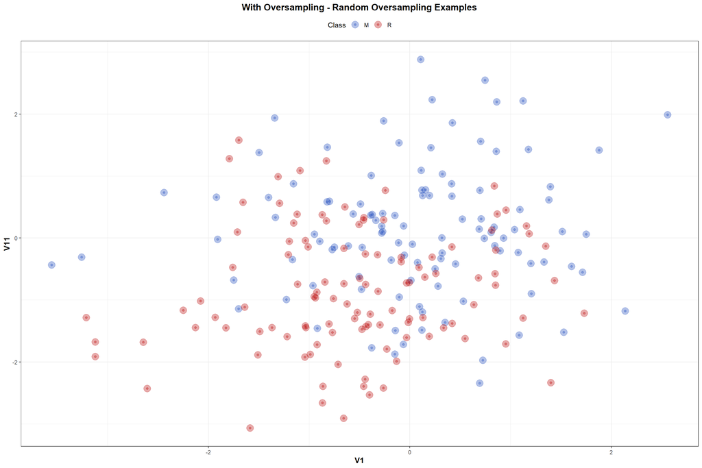

```r
##################################
# Implementing OS_ROSE
# Visualizing the oversampled data using OS_ROSE
##################################
recipe(Class ~ V1 + V11, data = PMA_PreModelling_Train) %>%
  step_rose(Class, seed=123456789) %>%
  prep() %>%
  bake(new_data = NULL) %>%
  ggplot(aes(V1, V11, color = Class)) +
  geom_point() +
  scale_colour_manual(values=c("#1846BA55","#B8000055")) +
  geom_point(size=5) +
  labs(title = "With Oversampling - Random Oversampling Examples") +
  theme_bw() +
  theme(plot.title = element_text(color="black", size=14, face="bold", hjust=0.50),
        axis.title.x = element_text(color="black", size=12, face="bold"),
        axis.title.y = element_text(color="black", size=12, face="bold"),
        legend.position="top")
```

```r
OS_ROSE <- recipe(Class ~ V1 + V11, data = PMA_PreModelling_Train) %>%
  step_rose(Class, seed=123456789) %>%
  prep()

PMA_PreModelling_Train_LR_OS_ROSE <- OS_ROSE %>%
bake(new_data = NULL)

(PMA_PreModelling_Train_LR_OS_ROSE <- as.data.frame(PMA_PreModelling_Train_LR_OS_ROSE))
```

```
##               V1          V11 Class
## 1    0.453829274 -0.420221366     M
## 2    0.127920224  0.686476420     M
## 3    1.075595629 -0.235554656     M
## 4    2.137901379 -1.178271820     M
## 5    1.092110905  0.456926231     M
## 6    0.857402441  1.398298653     M
## 7   -1.907459325 -0.021176979     M
## 8    0.309616027 -0.332458449     M
## 9    0.693229730 -2.341819879     M
## 10   1.716214396 -0.555582217     M
## 11  -0.770935156 -0.187998880     M
## 12  -1.496837087  1.378598435     M
## 13  -0.106000306  1.534889807     M
## 14  -0.916802330 -1.457363172     M
```

[output cut: 208 more lines]

```r
PMA_PreModelling_Train_LR_OS_ROSE$Label <- rep("LR_OS_ROSE",nrow(PMA_PreModelling_Train_LR_OS_ROSE))

##################################
# Verifying the class distribution
# for the oversampled data using OS_ROSE
##################################
table(PMA_PreModelling_Train_LR_OS_ROSE$Class)
```

```
##
##   M   R
## 110 112
```

```r
##################################
# Formulating the structure of the
# Logistic Regression model
##################################
LR_OS_ROSE_Model <- glm(Class ~ V1 + V11,
                data = PMA_PreModelling_Train_LR_OS_ROSE,
                family = binomial)

##################################
# Consolidating the model results
##################################
summary(LR_OS_ROSE_Model)
```

```
##
## Call:
## glm(formula = Class ~ V1 + V11, family = binomial, data = PMA_PreModelling_Train_LR_OS_ROSE)
##
## Deviance Residuals:
##     Min       1Q   Median       3Q      Max
## -1.9858  -0.9400   0.2881   0.9195   1.9172
##
## Coefficients:
##             Estimate Std. Error z value Pr(>|z|)
## (Intercept)  -0.4555     0.1701  -2.678 0.007398 **
## V1           -0.5284     0.1593  -3.317 0.000908 ***
## V11          -0.9132     0.1650  -5.535 3.11e-08 ***
## ---
## Signif. codes:  0 '***' 0.001 '**' 0.01 '*' 0.05 '.' 0.1 ' ' 1
##
## (Dispersion parameter for binomial family taken to be 1)
##
##     Null deviance: 307.74  on 221  degrees of freedom
## Residual deviance: 249.98  on 219  degrees of freedom
## AIC: 255.98
##
## Number of Fisher Scoring iterations: 4
```

```r
LR_OS_ROSE_Model_Coef <- (as.data.frame(LR_OS_ROSE_Model$coefficients))
LR_OS_ROSE_Model_Coef$Coef <- rownames(LR_OS_ROSE_Model_Coef)
LR_OS_ROSE_Model_Coef$Model <- rep("LR_OS_ROSE",nrow(LR_OS_ROSE_Model_Coef))
colnames(LR_OS_ROSE_Model_Coef) <- c("Estimates","Coefficients","Model")
print(LR_OS_ROSE_Model_Coef, rownames=FALSE)
```

```
##              Estimates Coefficients      Model
## (Intercept) -0.4555392  (Intercept) LR_OS_ROSE
## V1          -0.5283578           V1 LR_OS_ROSE
## V11         -0.9131847          V11 LR_OS_ROSE
```

```r
##################################
# Computing the model predictions
##################################
(LR_OS_ROSE_Model_Probabilities <- predict(LR_OS_ROSE_Model,
                              type = c("response")))
```

```
##          1          2          3          4          5          6          7
## 0.42272822 0.24048787 0.30816041 0.37539602 0.19002887 0.10106385 0.63913697
##          8          9         10         11         12         13         14
## 0.42176519 0.78863241 0.29839231 0.53082787 0.28422724 0.14170857 0.79571130
##         15         16         17         18         19         20         21
## 0.22330577 0.75894563 0.41991396 0.63880235 0.49785184 0.74799586 0.27924052
##         22         23         24         25         26         27         28
## 0.37505987 0.46687195 0.54125677 0.53154810 0.02608136 0.35805690 0.68056655
##         29         30         31         32         33         34         35
## 0.05131761 0.24480950 0.81543281 0.49588602 0.51951627 0.40614035 0.23464164
##         36         37         38         39         40         41         42
## 0.13070302 0.32982442 0.79130846 0.33800037 0.59903625 0.82478350 0.06863251
##         43         44         45         46         47         48         49
## 0.18028811 0.04447561 0.48934125 0.34825343 0.35375905 0.18642890 0.36923822
##         50         51         52         53         54         55         56
## 0.33217220 0.25777606 0.20450560 0.26753625 0.46612769 0.27596505 0.69824553
##         57         58         59         60         61         62         63
## 0.27972403 0.29238147 0.06060725 0.11495790 0.61760221 0.48333050 0.39953443
##         64         65         66         67         68         69         70
## 0.23594946 0.04138595 0.32870381 0.72784589 0.14861986 0.12477099 0.62351399
##         71         72         73         74         75         76         77
## 0.17900745 0.52700098 0.36494339 0.18093261 0.17230032 0.30917596 0.59405330
##         78         79         80         81         82         83         84
## 0.38163331 0.20601548 0.48623520 0.04006559 0.42269894 0.86079066 0.36046859
##         85         86         87         88         89         90         91
## 0.34420429 0.43261336 0.51611451 0.40736875 0.24799075 0.63513227 0.54858837
##         92         93         94         95         96         97         98
## 0.31319703 0.40034265 0.61582913 0.74997077 0.35432276 0.49167898 0.30177638
##         99        100        101        102        103        104        105
## 0.19216831 0.54032242 0.09540200 0.64698261 0.45722602 0.08517833 0.79664657
##        106        107        108        109        110        111        112
## 0.32316339 0.72398394 0.08460516 0.21554948 0.22751830 0.72751777 0.67614219
##        113        114        115        116        117        118        119
## 0.44662821 0.60527575 0.55603100 0.86923142 0.55098545 0.51117317 0.26385700
##        120        121        122        123        124        125        126
## 0.89907501 0.46951683 0.66643143 0.73526461 0.48557423 0.22348101 0.15915581
##        127        128        129        130        131        132        133
## 0.65659701 0.24158944 0.73874767 0.96013708 0.55654831 0.82788619 0.53327752
##        134        135        136        137        138        139        140
## 0.26899165 0.95857559 0.71565046 0.63728241 0.71889102 0.61362934 0.44352519
```

[output cut: 9 more lines]

```
## 0.83765665 0.48297670 0.69649384 0.91937851 0.71333541 0.38379354 0.64209386
##        176        177        178        179        180        181        182
## 0.69963871 0.42768298 0.36110724 0.35809396 0.29493003 0.75795197 0.69280709
##        183        184        185        186        187        188        189
## 0.83032735 0.78613971 0.21975873 0.23963883 0.85638009 0.62177733 0.85028733
##        190        191        192        193        194        195        196
## 0.48388136 0.71240426 0.48272976 0.32564362 0.80352755 0.87778623 0.69777637
##        197        198        199        200        201        202        203
## 0.86209523 0.67669167 0.26826426 0.77504386 0.40478111 0.43288003 0.68929534
##        204        205        206        207        208        209        210
## 0.33730469 0.49041932 0.59971660 0.74680630 0.87975259 0.88742407 0.92266675
##        211        212        213        214        215        216        217
## 0.42994096 0.20253953 0.44794817 0.73667934 0.80704537 0.85607802 0.25961475
##        218        219        220        221        222
## 0.84668245 0.43507308 0.55222785 0.86535253 0.83237685
```

```r
##################################
# Creating a classification index
# based from the model predictions
##################################
(LR_OS_ROSE_Model_Indices <- predict(LR_OS_ROSE_Model,
                           type = c("link")))
```

```
##            1            2            3            4            5            6
## -0.311583732 -1.150006656 -0.808733670 -0.509136303 -1.449822617 -2.185459486
##            7            8            9           10           11           12
##  0.571620329 -0.315531291  1.316701585 -0.854965324  0.123468107 -0.923588677
##           13           14           15           16           17           18
## -1.801171064  1.359702258 -1.246504767  1.146907641 -0.323126605  0.570169780
##           19           20           21           22           23           24
## -0.008592705  1.087951913 -0.948232019 -0.510570169 -0.132706621  0.165403137
##           25           26           27           28           29           30
##  0.126360262 -3.620106864 -0.583807739  0.756376634 -2.917040046 -1.126489672
##           31           32           33           34           35           36
##  1.485705461 -0.016456294  0.078104777 -0.379944235 -1.182284732 -1.894757113
##           37           38           39           40           41           42
## -0.708979289  1.332830551 -0.672218011  0.401451079  1.549098576 -2.607887604
##           43           44           45           46           47           48
## -1.514396714 -3.067319346 -0.042641454 -0.626725333 -0.602556377 -1.473383381
##           49           50           51           52           53           54
## -0.535486224 -0.698376867 -1.057559759 -1.358368477 -1.007158785 -0.135697076
##           55           56           57           58           59           60
## -0.964565444  0.838957115 -0.945830902 -0.883845811 -2.740819106 -2.041069195
##           61           62           63           64           65           66
##  0.479383185 -0.066702727 -0.407405360 -1.175016290 -3.142547062 -0.714053376
##           67           68           69           70           71           72
##  0.983720838 -1.745466933 -1.948005631  0.504490295 -1.523086620  0.108109072
##           73           74           75           76           77           78
## -0.553971878 -1.510041697 -1.569411378 -0.803974603  0.380747178 -0.482621426
##           79           80           81           82           83           84
## -1.349112661 -0.055073129 -3.176347023 -0.311703691  1.821872477 -0.573330931
##           85           86           87           88           89           90
## -0.644613971 -0.271196583  0.064480356 -0.374853574 -1.109357179  0.554298385
##           91           92           93           94           95           96
##  0.194968769 -0.785214949 -0.404037608  0.471882126  1.098456379 -0.600091505
##           97           98           99          100          101          102
## -0.033287169 -0.838853164 -1.435982099  0.161640704 -2.249391106  0.605802116
##          103          104          105          106          107          108
## -0.171515133 -2.373982082  1.365465607 -0.739271854  0.964310162 -2.381360181
##          109          110          111          112          113          114
## -1.291793024 -1.222377651  0.982065023  0.736098817 -0.214303591  0.427496730
##          115          116          117          118          119          120
##  0.225069325  1.894180197  0.204653127  0.044700141 -1.026017110  2.186988947
```

[output cut: 19 more lines]

```
##  0.584463706  0.845578033 -0.291310863 -0.570561627 -0.583646521 -0.871558923
##          181          182          183          184          185          186
##  1.141483829  0.813275667  1.587949042  1.301811601 -1.267072947 -1.154660623
##          187          188          189          190          191          192
##  1.785544023  0.497098959  1.736856426 -0.064496902  0.907089741 -0.069108460
##          193          194          195          196          197          198
## -0.727955121  1.408489278  1.971631378  0.836731432  1.832802349  0.738609301
##          199          200          201          202          203          204
## -1.003446893  1.237014177 -0.385582774 -0.270110234  0.796827032 -0.675328688
##          205          206          207          208          209          210
## -0.038327405  0.404284424  1.081651042  1.990089307  2.064695003  2.479144060
##          211          212          213          214          215          216
## -0.282092041 -1.370497185 -0.208964397  1.028780156  1.430924825  1.783090147
##          217          218          219          220          221          222
## -1.047971859  1.708814429 -0.261182377  0.209676238  1.860476975  1.602567012
```

```r
max(LR_OS_ROSE_Model_Indices)
```

```
## [1] 3.181629
```

```r
min(LR_OS_ROSE_Model_Indices)
```

```
## [1] -3.620107
```

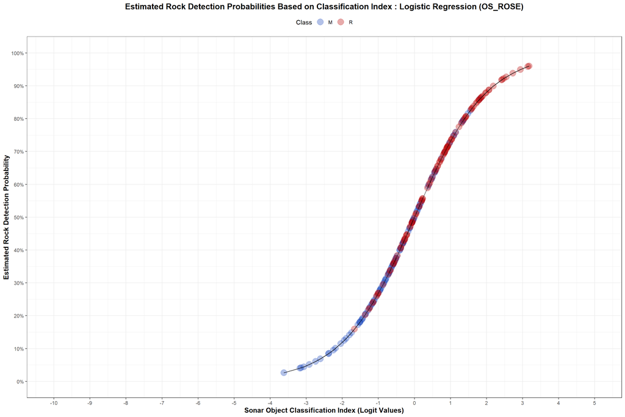

```r
##################################
# Consolidating the model probabilities
# and classification index
# based from the model predictions
##################################
LR_OS_ROSE_Model_Predictions <- as.data.frame(PMA_PreModelling_Train_LR_OS_ROSE)
LR_OS_ROSE_Model_Predictions$LR_OS_ROSE_Prob <- LR_OS_ROSE_Model_Probabilities
LR_OS_ROSE_Model_Predictions$LR_OS_ROSE_LP <- LR_OS_ROSE_Model_Indices
LR_OS_ROSE_Model_Predictions$Class <- as.factor(LR_OS_ROSE_Model_Predictions$Class)
LR_OS_ROSE_Model_Predictions$Label <- rep("LR_OS_ROSE",nrow(LR_OS_ROSE_Model_Predictions))

##################################
# Formulating the probability curve
# using the consolidated model predictions
##################################
LR_OS_ROSE_Model_Predictions %>%
  ggplot(aes(x = LR_OS_ROSE_LP ,
             y = LR_OS_ROSE_Prob,
             color = Class)) +
  scale_colour_manual(values=c("#1846BA55","#B8000055")) +
  geom_point(size=5) +
  geom_line(color="black") +
  xlab("Sonar Object Classification Index (Logit Values)") +
  ylab("Estimated Rock Detection Probability") +
  labs(color = "Class") +
  scale_x_continuous( limits=c(-10,5), breaks=seq(-10,5,by=1)) +
  scale_y_continuous( limits=c(0,1), breaks=seq(0,1,by=0.1),labels = scales::percent) +
  ggtitle("Estimated Rock Detection Probabilities Based on Classification Index : Logistic Regression (OS_ROSE)") +
  theme_bw() +
  theme(plot.title = element_text(color="black", size=14, face="bold", hjust=0.50),
        axis.title.x = element_text(color="black", size=12, face="bold"),
        axis.title.y = element_text(color="black", size=12, face="bold"),
        legend.position="top")
```

## 1.6 Evaluation Summary

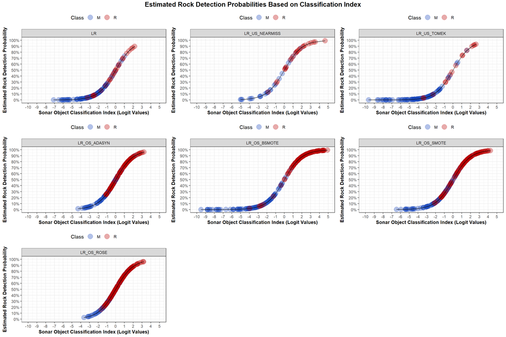

```r
##################################
# Replotting the logistic curves
##################################
LR_LogisticCurvePlot <- LR_Model_Predictions %>%
  ggplot(aes(x = LR_LP ,
             y = LR_Prob,
             color = Class)) +
  scale_colour_manual(values=c("#1846BA55","#B8000055")) +
  geom_point(size=5) +
  geom_line(color="black") +
  xlab("Sonar Object Classification Index (Logit Values)") +
  ylab("Estimated Rock Detection Probability") +
  labs(color = "Class") +
  scale_x_continuous( limits=c(-10,5), breaks=seq(-10,5,by=1)) +
  scale_y_continuous( limits=c(0,1), breaks=seq(0,1,by=0.1),labels = scales::percent) +
  facet_grid(. ~ Label) +
  theme_bw() +
  theme(plot.title = element_text(color="black", size=14, face="bold", hjust=0.50),
        axis.title.x = element_text(color="black", size=10, face="bold"),
        axis.title.y = element_text(color="black", size=10, face="bold"),
        legend.position="top")

LR_US_NEARMISS_LogisticCurvePlot <- LR_US_NEARMISS_Model_Predictions %>%
  ggplot(aes(x = LR_US_NEARMISS_LP ,
             y = LR_US_NEARMISS_Prob,
             color = Class)) +
  scale_colour_manual(values=c("#1846BA55","#B8000055")) +
  geom_point(size=5) +
  geom_line(color="black") +
  xlab("Sonar Object Classification Index (Logit Values)") +
  ylab("Estimated Rock Detection Probability") +
  labs(color = "Class") +
  scale_x_continuous( limits=c(-10,5), breaks=seq(-10,5,by=1)) +
  scale_y_continuous( limits=c(0,1), breaks=seq(0,1,by=0.1),labels = scales::percent) +
  facet_grid(. ~ Label) +
  theme_bw() +
  theme(plot.title = element_text(color="black", size=14, face="bold", hjust=0.50),
        axis.title.x = element_text(color="black", size=10, face="bold"),
        axis.title.y = element_text(color="black", size=10, face="bold"),
        legend.position="top")

LR_US_TOMEK_LogisticCurvePlot <- LR_US_TOMEK_Model_Predictions %>%
  ggplot(aes(x = LR_US_TOMEK_LP ,
             y = LR_US_TOMEK_Prob,
             color = Class)) +
  scale_colour_manual(values=c("#1846BA55","#B8000055")) +
  geom_point(size=5) +
  geom_line(color="black") +
  xlab("Sonar Object Classification Index (Logit Values)") +
  ylab("Estimated Rock Detection Probability") +
  labs(color = "Class") +
  scale_x_continuous( limits=c(-10,5), breaks=seq(-10,5,by=1)) +
  scale_y_continuous( limits=c(0,1), breaks=seq(0,1,by=0.1),labels = scales::percent) +
  facet_grid(. ~ Label) +
  theme_bw() +
  theme(plot.title = element_text(color="black", size=14, face="bold", hjust=0.50),
        axis.title.x = element_text(color="black", size=10, face="bold"),
        axis.title.y = element_text(color="black", size=10, face="bold"),
        legend.position="top")

LR_OS_ADASYN_LogisticCurvePlot <-  LR_OS_ADASYN_Model_Predictions %>%
  ggplot(aes(x = LR_OS_ADASYN_LP ,
             y = LR_OS_ADASYN_Prob,
             color = Class)) +
  scale_colour_manual(values=c("#1846BA55","#B8000055")) +
  geom_point(size=5) +
  geom_line(color="black") +
  xlab("Sonar Object Classification Index (Logit Values)") +
  ylab("Estimated Rock Detection Probability") +
  labs(color = "Class") +
  scale_x_continuous( limits=c(-10,5), breaks=seq(-10,5,by=1)) +
  scale_y_continuous( limits=c(0,1), breaks=seq(0,1,by=0.1),labels = scales::percent) +
  facet_grid(. ~ Label) +
  theme_bw() +
  theme(plot.title = element_text(color="black", size=14, face="bold", hjust=0.50),
        axis.title.x = element_text(color="black", size=10, face="bold"),
        axis.title.y = element_text(color="black", size=10, face="bold"),
        legend.position="top")

LR_OS_BSMOTE_LogisticCurvePlot <-  LR_OS_BSMOTE_Model_Predictions %>%
  ggplot(aes(x = LR_OS_BSMOTE_LP ,
             y = LR_OS_BSMOTE_Prob,
             color = Class)) +
  scale_colour_manual(values=c("#1846BA55","#B8000055")) +
  geom_point(size=5) +
  geom_line(color="black") +
  xlab("Sonar Object Classification Index (Logit Values)") +
  ylab("Estimated Rock Detection Probability") +
  labs(color = "Class") +
  scale_x_continuous( limits=c(-10,5), breaks=seq(-10,5,by=1)) +
  scale_y_continuous( limits=c(0,1), breaks=seq(0,1,by=0.1),labels = scales::percent) +
  facet_grid(. ~ Label) +
  theme_bw() +
  theme(plot.title = element_text(color="black", size=14, face="bold", hjust=0.50),
        axis.title.x = element_text(color="black", size=10, face="bold"),
        axis.title.y = element_text(color="black", size=10, face="bold"),
        legend.position="top")

LR_OS_SMOTE_LogisticCurvePlot <-  LR_OS_SMOTE_Model_Predictions %>%
  ggplot(aes(x = LR_OS_SMOTE_LP ,
             y = LR_OS_SMOTE_Prob,
             color = Class)) +
  scale_colour_manual(values=c("#1846BA55","#B8000055")) +
  geom_point(size=5) +
  geom_line(color="black") +
  xlab("Sonar Object Classification Index (Logit Values)") +
  ylab("Estimated Rock Detection Probability") +
  labs(color = "Class") +
  scale_x_continuous( limits=c(-10,5), breaks=seq(-10,5,by=1)) +
  scale_y_continuous( limits=c(0,1), breaks=seq(0,1,by=0.1),labels = scales::percent) +
  facet_grid(. ~ Label) +
  theme_bw() +
  theme(plot.title = element_text(color="black", size=14, face="bold", hjust=0.50),
        axis.title.x = element_text(color="black", size=10, face="bold"),
        axis.title.y = element_text(color="black", size=10, face="bold"),
        legend.position="top")

LR_OS_ROSE_LogisticCurvePlot <-  LR_OS_ROSE_Model_Predictions %>%
  ggplot(aes(x = LR_OS_ROSE_LP ,
             y = LR_OS_ROSE_Prob,
             color = Class)) +
  scale_colour_manual(values=c("#1846BA55","#B8000055")) +
  geom_point(size=5) +
  geom_line(color="black") +
  xlab("Sonar Object Classification Index (Logit Values)") +
  ylab("Estimated Rock Detection Probability") +
  labs(color = "Class") +
  scale_x_continuous( limits=c(-10,5), breaks=seq(-10,5,by=1)) +
  scale_y_continuous( limits=c(0,1), breaks=seq(0,1,by=0.1),labels = scales::percent) +
  facet_grid(. ~ Label) +
  theme_bw() +
  theme(plot.title = element_text(color="black", size=14, face="bold", hjust=0.50),
        axis.title.x = element_text(color="black", size=10, face="bold"),
        axis.title.y = element_text(color="black", size=10, face="bold"),
        legend.position="top")

RLR_LogisticCurvePlot <- ggarrange(LR_LogisticCurvePlot,
                                   LR_US_NEARMISS_LogisticCurvePlot,
                                   LR_US_TOMEK_LogisticCurvePlot,
                                   LR_OS_ADASYN_LogisticCurvePlot,
                                   LR_OS_BSMOTE_LogisticCurvePlot,
                                   LR_OS_SMOTE_LogisticCurvePlot,
                                   LR_OS_ROSE_LogisticCurvePlot,
                                   ncol=3, nrow=3)

annotate_figure(RLR_LogisticCurvePlot,
                top = text_grob("Estimated Rock Detection Probabilities Based on Classification Index",
                                color = "black",
                                face = "bold",
                                size = 14))
```

# **2. References**

**[Book]** [Applied Predictive Modeling](http://appliedpredictivemodeling.com/) by Max Kuhn and Kjell Johnson  
**[Book]** [An Introduction to Statistical Learning](https://www.statlearning.com/) by Gareth James, Daniela Witten, Trevor Hastie and Rob Tibshirani  
**[Book]** [Multivariate Data Visualization with R](http://lmdvr.r-forge.r-project.org/figures/figures.html) by Deepayan Sarkar  
**[Book]** [Machine Learning](https://bookdown.org/ssjackson300/Machine-Learning-Lecture-Notes/) by Samuel Jackson  
**[Book]** [Data Modeling Methods](https://bookdown.org/larget_jacob/data-modeling-methods/) by Jacob Larget  
**[R Package]** [AppliedPredictiveModeling](https://cran.r-project.org/web//packages/AppliedPredictiveModeling/AppliedPredictiveModeling.pdf) by Max Kuhn  
**[R Package]** [caret](https://topepo.github.io/caret/index.html) by Max Kuhn  
**[R Package]** [rpart](https://mran.microsoft.com/web/packages/rpart/rpart.pdf) by Terry Therneau and Beth Atkinson  
**[R Package]** [lattice](https://cran.r-project.org/web/packages/lattice/lattice.pdf) by Deepayan Sarkar  
**[R Package]** [dplyr](https://cran.r-project.org/web/packages/dplyr/index.html/) by Hadley Wickham  
**[R Package]** [moments](https://cran.r-project.org/web/packages/moments/index.html) by Lukasz Komsta and Frederick  
**[R Package]** [skimr](https://cran.r-project.org/web/packages/skimr/skimr.pdf) by Elin Waring  
**[R Package]** [RANN](https://cran.r-project.org/web/packages/RANN/RANN.pdf) by Sunil Arya, David Mount, Samuel Kemp and Gregory Jefferis  
**[R Package]** [corrplot](https://cran.r-project.org/web/packages/corrplot/corrplot.pdf) by Taiyun Wei  
**[R Package]** [tidyverse](https://cran.r-project.org/web/packages/tidyverse/tidyverse.pdf) by Hadley Wickham  
**[R Package]** [lares](https://cran.rstudio.com/web/packages/lares/lares.pdf) by Bernardo Lares  
**[R Package]** [DMwR](https://mran.microsoft.com/snapshot/2016-05-02/web/packages/DMwR/DMwR.pdf) by Luis Torgo  
**[R Package]** [gridExtra](https://cran.r-project.org/web/packages/gridExtra/gridExtra.pdf) by Baptiste Auguie and Anton Antonov  
**[R Package]** [rattle](https://cran.r-project.org/web/packages/rattle/rattle.pdf) by Graham Williams  
**[R Package]** [rpart.plot](https://cran.r-project.org/web/packages/rpart.plot/rpart.plot.pdf) by Stephen Milborrow  
**[R Package]** [RColorBrewer](https://cran.r-project.org/web//packages/RColorBrewer/RColorBrewer.pdf) by Erich Neuwirth  
**[R Package]** [stats](https://search.r-project.org/R/refmans/stats/html/00Index.html) by R Core Team  
**[R Package]** [pls](https://cran.r-project.org/web/packages/pls/pls.pdf) by Kristian Hovde Liland  
**[R Package]** [nnet](https://cran.r-project.org/web/packages/nnet/nnet.pdf) by Brian Ripley  
**[R Package]** [elasticnet](https://cran.r-project.org/web/packages/elasticnet/elasticnet.pdf) by Hui Zou  
**[R Package]** [earth](https://cran.r-project.org/web/packages/earth/earth.pdf) by Stephen Milborrow  
**[R Package]** [party](https://cran.r-project.org/web/packages/party/party.pdf) by Torsten Hothorn  
**[R Package]** [kernlab](https://cran.r-project.org/web/packages/kernlab/kernlab.pdf) by Alexandros Karatzoglou  
**[R Package]** [randomForest](https://cran.r-project.org/web/packages/randomForest/randomForest.pdf) by Andy Liaw  
**[R Package]** [pROC](https://cran.r-project.org/web/packages/pROC/pROC.pdf) by Xavier Robin  
**[R Package]** [mda](https://cran.r-project.org/web/packages/mda/mda.pdf) by Trevor Hastie  
**[R Package]** [klaR](https://cran.r-project.org/web/packages/klaR/klaR.pdf) by Christian Roever, Nils Raabe, Karsten Luebke, Uwe Ligges, Gero Szepannek, Marc Zentgraf and David Meyer  
**[R Package]** [pamr](https://cran.r-project.org/web/packages/pamr/pamr.pdf) by Trevor Hastie, Rob Tibshirani, Balasubramanian Narasimhan and Gil Chu  
**[R Package]** [ROSE](https://cran.r-project.org/web/packages/ROSE/ROSE.pdf) by Nicola Lunardon  
**[R Package]** [themis](https://cran.r-project.org/web/packages/themis/themis.pdf) by Emil Hvitfeldt  
**[Article]** [The caret Package](https://topepo.github.io/caret/index.html) by Max Kuhn  
**[Article]** [A Short Introduction to the caret Package](https://cran.r-project.org/web/packages/caret/vignettes/caret.html) by Max Kuhn  
**[Article]** Caret Package – A Practical Guide to Machine Learning in R by Selva Prabhakaran  
**[Article]** [Tuning Machine Learning Models Using the Caret R Package](https://machinelearningmastery.com/tuning-machine-learning-models-using-the-caret-r-package/) by Jason Brownlee  
**[Article]** [Lattice Graphs](http://www.sthda.com/english/wiki/lattice-graphs) by Alboukadel Kassambara  
**[Article]** [A Tour of Machine Learning Algorithms](https://machinelearningmastery.com/a-tour-of-machine-learning-algorithms/) by Jason Brownlee  
**[Article]** [Decision Tree Algorithm Examples In Data Mining](https://www.softwaretestinghelp.com/decision-tree-algorithm-examples-data-mining/) by Software Testing Help Team  
**[Article]** [4 Types of Classification Tasks in Machine Learning](https://machinelearningmastery.com/types-of-classification-in-machine-learning/) by Jason Brownlee  
**[Article]** [Spot-Check Classification Machine Learning Algorithms in Python with scikit-learn](https://machinelearningmastery.com/spot-check-classification-machine-learning-algorithms-python-scikit-learn/) by Jason Brownlee  
**[Article]** [Feature Engineering and Selection: A Practical Approach for Predictive Models](http://www.feat.engineering/index.html) by Max Kuhn and Kjell Johnson  
**[Article]** [Machine Learning Tutorial: A Step-by-Step Guide for Beginners](http://www.feat.engineering/index.html) by Mayank Banoula  
**[Article]** [Classification Tree](https://support.bccvl.org.au/support/solutions/articles/6000083204-classification-tree) by BCCVL Team  
**[Article]** [A Gentle Introduction to Imbalanced Classification](https://machinelearningmastery.com/what-is-imbalanced-classification/) by Jason Brownlee  
**[Article]** 8 Tactics to Combat Imbalanced Classes in Your Machine Learning Dataset by Jason Brownlee  
**[Article]** [Step-By-Step Framework for Imbalanced Classification Projects](https://machinelearningmastery.com/framework-for-imbalanced-classification-projects/) by Jason Brownlee  
**[Article]** [How to Handle Imbalanced Classes in Machine Learning](https://elitedatascience.com/imbalanced-classes) by Elite Data Science Team  
**[Article]** [Best Ways To Handle Imbalanced Data in Machine Learning](https://dataaspirant.com/handle-imbalanced-data-machine-learning/) by Jaiganesh Nagidi  
**[Article]** [Handling Imbalanced Data for Classification](https://www.geeksforgeeks.org/handling-imbalanced-data-for-classification/) by Geeks For Geeks Team  
**[Article]** Random Oversampling and Undersampling for Imbalanced Classification by Jason Brownlee  
**[Publication]** [SMOTE: Synthetic Minority Over-Sampling Technique](https://dl.acm.org/doi/10.5555/1622407.1622416) by Nitesh Chawla, Kevin Bowyer, Lawrence Hall and Philip Kegelmeyer (Journal of Artificial Intelligence Research)  
**[Publication]** [Training and Assessing Classification Rules with Imbalanced Data](https://link.springer.com/article/10.1007/s10618-012-0295-5) by Giovanna Menardi and Nicola Torelli (Data Mining and Knowledge Discovery)  
**[Publication]** [A Study of the Behavior of Several Methods for Balancing Machine Learning Training Data](https://dl.acm.org/doi/10.1145/1007730.1007735) by Gustavo Batista, Ronaldo Prati and Maria Carolina Monard (ACM SIGKDD Explorations Newsletter)  
**[Publication]** [A Survey of Predictive Modelling under Imbalanced Distributiona](https://arxiv.org/abs/1505.01658) by Paula Branco, Luis Torgo and Rita Ribeiro (Arxiv Cornell University)  
**[Course]** [Applied Data Mining and Statistical Learning](https://online.stat.psu.edu/stat508/) by Penn State Eberly College of Science  
**[Course]** [Regression Methods](https://online.stat.psu.edu/stat501/) by Penn State Eberly College of Science  
**[Course]** [Applied Regression Analysis](https://online.stat.psu.edu/stat462/) by Penn State Eberly College of Science  
**[Course]** [Applied Data Mining and Statistical Learning](https://online.stat.psu.edu/stat508/) by Penn State Eberly College of Science